# CNP Nutrition Signature Validation

ANOVA, ROC/AUC, logistic regression and random forest — leave-one-out internal and cross-dataset external validation

November 04, 2026

# Overview

This report tests whether each nutrition signature in `Signatures/NutSignaturesList.R` separates **low-nutrient** samples from **replete or nutrient-treated** samples in the public datasets downloaded by `Scripts/download_cnp_source_data.R` and processed by `Scripts/process_cnp_source_data.R`.

Signatures come from two places: the **curated** list (`Signatures/NutSignaturesList.R`, not modified) and **candidate** lists in `Signatures/CNP_Candidate_Signatures.csv`, produced by `Scripts/derive_candidate_signatures.R` to fill gaps (GWAS-based vitamin E, vitamin K and carnitine lists; a symbol-corrected vitamin E list; vitamin K lists re-derived from GSE148011). Each signature’s section states its source.

## Methods in brief

[output not shown]

**Case = low nutrient** throughout: deficient diet, untreated/vehicle cells, or the no-supplement arm. For treatment studies (calcitriol, ATRA, vitamin K precursor), the vehicle arm is the “case”, so an AUC above 0.5 means the signature tracks nutrient *exposure*, not necessarily clinical deficiency.

## Datasets and contrasts

| Panel | Dataset | Species | Platform | Units | Case (low) | Control (replete) | n | Covariates |
| --- | --- | --- | --- | --- | --- | --- | --- | --- |
| Vitamin A | GSE134933 kidney · mouse VAD diet | Mus musculus | RNA-seq (GPL13112) | log2(FPKM+1) | VAD | Chow | 7 vs 7 | genotype |
|  | GSE134933 liver · mouse VAD diet | Mus musculus | RNA-seq (GPL13112) | log2(FPKM+1) | VAD | Chow | 3 vs 3 | — |
|  | GSE299530 lung · mouse VAD diet | Mus musculus | RNA-seq (GPL35938/GPL35939) | log2 CPM | VAD | VAS | 16 vs 16 | timepoint, batch |
|  | GSE37313 liver · rat VAD diet | Rattus norvegicus | Illumina RatRef-12 (GPL6101) | log2 intensity | VAD_Vehicle | VAS_Vehicle | 9 vs 9 | surgery |
|  | GSE46268 monocytes · human ATRA | Homo sapiens | Affymetrix HG-U133 Plus 2 (GPL570) | log2 MAS5 | Control | ATRA | 4 vs 4 | donor |
| Vitamin D | GSE63086 MG63 · human 1,25D | Homo sapiens | RNA-seq (GPL16791) | log2 CPM (NCBI counts) | Vehicle | Calcitriol | 6 vs 6 | knockdown |
|  | GSE221690 prostate lines · human 1,25D | Homo sapiens | RNA-seq (GPL16791) | log2 CPM (NCBI counts) | Vehicle | Calcitriol | 12 vs 12 | cell_line |
|  | GSE15947 RWPE1 · human 1,25D | Homo sapiens | Affymetrix HG-U133 Plus 2 (GPL570) | log2 intensity (RMA) | Vehicle | Calcitriol | 12 vs 12 | time |
|  | GSE46268 monocytes · human 1,25D | Homo sapiens | Affymetrix HG-U133 Plus 2 (GPL570) | log2 MAS5 | Control | Calcitriol | 4 vs 4 | donor |
|  | GSE283020 TH2 · mouse VitD-deficient diet | Mus musculus | RNA-seq (GPL17021) | log2 CPM | VitD_deficient | Regular | 7 vs 3 | batch |
| Vitamin C | GSE233598 liver · mouse Gulo-/- no vitC | Mus musculus | RNA-seq (GPL24247) | log2(TPM+1) | Gulo_0pct | Gulo_0.40pct + WT | 6 vs 12 | sex |
|  | GSE190371 kidney · mouse Gulo-/- (pseudobulk) | Mus musculus | scRNA-seq pseudobulk (GPL21273) | log2 CPM (summed UMIs) | VitC_deficient | Control | 2 vs 2 | — |
|  | GSE295923 embryo headfold · mouse Gulo-/- maternal vitC | Mus musculus | RNA-seq (GPL24247) | log2 CPM | VitC_minus | VitC_plus | 15 vs 14 | background, sex |
| Vitamin B12 / methyl donors | GSE161763 brain · mouse cblX (Ronin F80L) | Mus musculus | RNA-seq (GPL17021) | log2 CPM | cblX_F80L | Control | 3 vs 3 | — |
|  | GSE103417 N1E-115 · mouse B12 sequestration | Mus musculus | Agilent Whole Mouse Genome (GPL4134) | log2 intensity | TO_B12_sequestered | WT + OT_control_fusion | 8 vs 16 | medium |
|  | GSE104164 cerebellum · rat methyl-donor deficiency | Rattus norvegicus | Agilent Rat Gene Expression (GPL14797) | log2 intensity | MDD | Control | 3 vs 4 | — |
|  | GSE99113 astrocytes · mouse B12-free medium | Mus musculus | RNA-seq (GPL19057) | log2(normalised expression+1) | B12_deficient | B12_sufficient | 2 vs 2 | — |
| Folate | GSE275393 E11.5 brain · mouse maternal FA 0.1 ppm | Mus musculus | RNA-seq | log2 CPM | FA_0.1ppm | FA_3ppm + FA_30ppm | 15 vs 25 | genotype, sex |
|  | GSE324232 germ cells · mouse folate-deficient diet | Mus musculus | RNA-seq | log2 CPM | Folate_deficient | Folate_sufficient | 6 vs 6 | cell_type |
|  | GSE104164 cerebellum · rat methyl-donor deficiency | Rattus norvegicus | Agilent Rat Gene Expression (GPL14797) | log2 intensity | MDD | Control | 3 vs 4 | — |
|  | GSE271941 MEF · mouse moderate vs fortified FA | Mus musculus | RNA-seq | log2 CPM | Moderate_FA | Fortified_FA | 6 vs 6 | genotype |
| Vitamin B6 | GSE345689 kidney · mouse low vs high B6 diet | Mus musculus | RNA-seq (GPL24247) | log2(FPKM+1) | Low_B6 | High_B6 | 6 vs 6 | genotype |
|  | GSE139892 leukemic cells · mouse B6 antagonist | Mus musculus | RNA-seq | log2(RPKM+1) | OMP_B6_antagonist | Vehicle | 3 vs 3 | — |
| Vitamin E | GSE110747 liver · mouse vitamin E diet | Mus musculus | Affymetrix Mouse Gene 2.0 ST (GPL17400) | log2 intensity (as deposited) | Control_diet | VitE_diet | 22 vs 22 | exercise |
|  | GSE1063 · rat vitamin E-deficient diet | Rattus norvegicus | Clontech Atlas Rat 1.2 (GPL155) | log2 intensity | VitE_deficient | VitE_sufficient | 5 vs 5 | — |
|  | GSE8150 brain · aged mouse tocopherol | Mus musculus | Affymetrix MOE430 2.0 (GPL1261) | log2 MAS5 | Old_control | Old_aT + Old_aT_gT | 5 vs 10 | — |
|  | GSE8146 heart · aged mouse tocopherol | Mus musculus | Affymetrix MG-U74Av2 (GPL81) | log2 MAS5 | Old_control | Old_aT + Old_aT_gT | 5 vs 10 | — |
|  | GSE195619 HepaRG · human oleic acid ± vitamin E | Homo sapiens | Affymetrix GO_Screen_hu (GPL31262) | log2 intensity | OA | OA_nVE + OA_sVE + OA_WGO_VE | 3 vs 8 | — |
| Carnitine | GSE343742 BMM · mouse L-carnitine ± LPS | Mus musculus | RNA-seq | log2(TPM+1) | Untreated + LPS | Carnitine + LPS_Carnitine | 6 vs 6 | lps |
|  | GSE344237 liver · mouse resveratrol + L-carnitine | Mus musculus | Agilent SurePrint G3 Mouse (GPL21163) | log2 intensity | CD + HFCD | CD+RCl + CD+RCh + HFCD+RCl + HFCD+RCh | 8 vs 16 | diet |
| Vitamin K | GSE148011 MEF · mouse vitamin K precursor | Mus musculus | RNA-seq (GPL19057) | log2 CPM | K3_0 | K3_10 + K3_20 | 4 vs 7 | — |
|  | GSE267133 ARPE-19 · human vitamin K1 (+ erastin) | Homo sapiens | RNA-seq | log2(FPKM+1) | Erastin | Erastin_VitK1 | 3 vs 3 | — |
|  | GSE237219 Jurkat · human vitamin K1 | Homo sapiens | RNA-seq | log2 CPM (NCBI counts) | Control | VitK1 | 2 vs 3 | — |
|  | GSE272401 BMDM · mouse RANKL ± vitamins D+K | Mus musculus | RNA-seq | log2(FPKM+1) | RANKL | RANKL_VitD_VitK | 3 vs 3 | — |
| Omega-3 | GSE12375 PBMC · human EPA/DHA vs MUFA, 6 mo | Homo sapiens | NuGO Hs1a520180 custom Affymetrix (GPL7144) | log2 intensity | MUFA_END | EPADHA_END | 25 vs 23 | — |
|  | GSE48368 PBMC · human fish oil vs HOSO, 7 wk | Homo sapiens | Illumina HumanHT-12 v4 (GPL10558) | log2 intensity | HOSO_wk7 | FO_wk7 | 19 vs 17 | — |
|  | GSE29680 PBMC · Alzheimer patients n-3 vs placebo, 6 mo | Homo sapiens | Affymetrix HG-Focus (GPL201) | log2 MAS5 | Placebo_after | n3_after | 5 vs 11 | — |
| Vitamin B1 | GSE31553 myotubes · human benfotiamine | Homo sapiens | Illumina HumanWG-6 v3 (GPL6884) | log2 intensity | No_benfotiamine | Benfotiamine | 6 vs 6 | glucose, donor |
| Vitamin B3 | GSE345595 liver · mouse niacin-free diet | Mus musculus | RNA-seq | log2 CPM | ND1DL + ND1DS + ND2D | CD1D + CD2W | 18 vs 12 | doxycycline |
|  | GSE345344 liver · mouse niacin-free diet / recovery | Mus musculus | RNA-seq | log2 CPM | NFD | CD + Rec | 4 vs 11 | — |
|  | GSE300498 intestine · mouse tryptophan/niacin-free diet | Mus musculus | RNA-seq | log2 CPM | TNR + MTNR | C | 4 vs 2 | strain |
|  | GSE92499 liver · mouse nicotinamide supplementation | Mus musculus | Illumina MouseWG-6 v2 (GPL6885) | log2 intensity (quantile-normalised from non-normalised file) | No_NAM | Low_NAM + High_NAM | 12 vs 20 | diet |
| Vitamin B5 | GSE130705 brain · mouse Pank1/2 knockout (CoA deficiency) | Mus musculus | RNA-seq (GPL17021) | log2 CPM | Pank1_Pank2_dKO | WT | 11 vs 12 | sex, day |
|  | GSE187456 Tc0 T cells · mouse coenzyme A | Mus musculus | RNA-seq (GPL13112) | log2 CPM | Untreated | CoA | 3 vs 3 | mouse |
| Iron | GSE162493 heart · mouse iron-deficient diet | Mus musculus | RNA-seq (GPL21103) | log2 CPM | Iron_deficient | Control | 10 vs 10 | — |
|  | GSE157667 placenta · mouse iron deficiency | Mus musculus | RNA-seq (GPL21103) | log2 CPM | Iron_deficient | Iron_adequate | 6 vs 6 | sex |
|  | GSE30533 liver · rat iron-deficient diet | Rattus norvegicus | Affymetrix Rat 230 2.0 (GPL1355) | log2 intensity | Iron_deficient | Control | 5 vs 5 | — |
|  | GSE175739 whole blood · heart-failure patients | Homo sapiens | Affymetrix HuGene 2.0 ST (GPL16686) | log2 intensity | Iron_deficient | Iron_replete | 7 vs 7 | pair |
|  | GSE314015 endothelial cells · human iron chelation | Homo sapiens | RNA-seq | log2 CPM | Deferoxamine | Vehicle | 6 vs 6 | cell_type |

# Summary of predictive performance

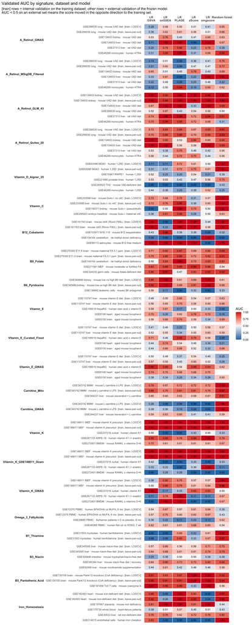

### Internal validation (leave-one-out AUC on the training dataset)

Leave-one-out (LOOCV) AUC

| signature | panel | Training | LR · GSVA | LR · ssGSEA | LR · PLAGE | LR · zScore | LR · singscore | Random forest |
| --- | --- | --- | --- | --- | --- | --- | --- | --- |
| A_Retinol_GWAS | Vitamin A | GSE299530 lung · mouse VAD diet | 0.28 | 0.58 | 0.55 | 0.51 | 0.41 | 0.65 |
| A_Retinol_MSigDB_Filtered | Vitamin A | GSE299530 lung · mouse VAD diet | 0.14 | 0.51 | 0.05 | 0.36 | 0.41 | 0.76 |
| A_Retinol_GLM_43 | Vitamin A | GSE134933 kidney · mouse VAD diet | 1.00 | 0.90 | 1.00 | 1.00 | 0.98 | 1.00 |
| A_Retinol_Quiles_20 | Vitamin A | GSE299530 lung · mouse VAD diet | 0.72 | 0.84 | 0.84 | 0.67 | 0.83 | 0.91 |
| Vitamin_D_Aigner_35 | Vitamin D | GSE63086 MG63 · human 1,25D | 0.11 | 0.11 | 0.72 | 0.61 | 0.50 | 1.00 |
| Vitamin_C | Vitamin C | GSE233598 liver · mouse Gulo-/- no vitC | 0.72 | 0.68 | 0.76 | 0.31 | 0.57 | 1.00 |
| B12_Cobalamin | Vitamin B12 / methyl donors | GSE161763 brain · mouse cblX (Ronin F80L) | 1.00 | 0.00 | 1.00 | 1.00 | 0.44 | 1.00 |
| B9_Folate | Folate | GSE275393 E11.5 brain · mouse maternal FA 0.1 ppm | 0.71 | 0.82 | 0.87 | 0.69 | 0.80 | 0.89 |
| B6_Pyridoxine | Vitamin B6 | GSE345689 kidney · mouse low vs high B6 diet | 0.86 | 1.00 | 0.61 | 0.69 | 1.00 | 0.61 |
| Vitamin_E | Vitamin E | GSE110747 liver · mouse vitamin E diet | 0.48 | 0.55 | 0.68 | 0.54 | 0.57 | 0.63 |
| Vitamin_E_Curated_Fixed | Vitamin E | GSE110747 liver · mouse vitamin E diet | 0.41 | 0.46 | 0.22 | 0.50 | 0.58 | 0.57 |
| Vitamin_E_GWAS | Vitamin E | GSE110747 liver · mouse vitamin E diet | 0.50 | 0.49 | 0.37 | 0.54 | 0.45 | 0.25 |
| Carnitine_Mito | Carnitine | GSE343742 BMM · mouse L-carnitine ± LPS | 0.78 | 0.67 | 0.72 | 0.72 | 0.72 | 1.00 |
| Carnitine_GWAS | Carnitine | GSE343742 BMM · mouse L-carnitine ± LPS | 0.28 | 0.06 | 0.08 | 0.00 | 0.00 | 1.00 |
| Vitamin_K | Vitamin K | GSE148011 MEF · mouse vitamin K precursor | 1.00 | 1.00 | 1.00 | 1.00 | 1.00 | 1.00 |
| Vitamin_K_GSE148011_Down | Vitamin K | GSE148011 MEF · mouse vitamin K precursor | 1.00 | 1.00 | 1.00 | 1.00 | 1.00 | 1.00 |
| Vitamin_K_GWAS | Vitamin K | GSE148011 MEF · mouse vitamin K precursor | 0.36 | 0.82 | 0.75 | 0.57 | 0.57 | 1.00 |
| Omega_3_FattyAcids | Omega-3 | GSE12375 PBMC · human EPA/DHA vs MUFA, 6 mo | 0.54 | 0.67 | 0.57 | 0.61 | 0.64 | 0.38 |
| B1_Thiamine | Vitamin B1 | GSE31553 myotubes · human benfotiamine | 0.00 | 0.00 | 0.69 | 0.22 | 0.61 | 1.00 |
| B3_Niacin | Vitamin B3 | GSE345595 liver · mouse niacin-free diet | 0.57 | 0.66 | 0.56 | 0.56 | 0.71 | 0.75 |
| B5_Pantothenic Acid | Vitamin B5 | GSE130705 brain · mouse Pank1/2 knockout (CoA deficiency) | 0.91 | 0.83 | 0.87 | 1.00 | 1.00 | 0.92 |
| Iron_Homeostasis | Iron | GSE162493 heart · mouse iron-deficient diet | 0.88 | 0.08 | 1.00 | 0.83 | 0.00 | 0.97 |

Leave-pair-out AUC (bias-corrected internal estimate)

| signature | LR · GSVA | LR · ssGSEA | LR · PLAGE | LR · zScore | LR · singscore | Random forest |
| --- | --- | --- | --- | --- | --- | --- |
| A_Retinol_GWAS | 0.36 | 0.62 | 0.61 | 0.56 | 0.51 | 0.66 |
| A_Retinol_MSigDB_Filtered | 0.21 | 0.60 | 0.09 | 0.47 | 0.47 | 0.77 |
| A_Retinol_GLM_43 | 1.00 | 0.94 | 1.00 | 1.00 | 1.00 | 1.00 |
| A_Retinol_Quiles_20 | 0.75 | 0.86 | 0.89 | 0.70 | 0.85 | 0.93 |
| Vitamin_D_Aigner_35 | 0.31 | 0.31 | 0.72 | 0.75 | 0.61 | 1.00 |
| Vitamin_C | 0.72 | 0.76 | 0.95 | 0.36 | 0.60 | 1.00 |
| B12_Cobalamin | 1.00 | 0.22 | 1.00 | 1.00 | 0.56 | 1.00 |
| B9_Folate | 0.75 | 0.85 | 0.89 | 0.72 | 0.82 | 0.91 |
| B6_Pyridoxine | 0.92 | 1.00 | 0.69 | 0.81 | 1.00 | 0.68 |
| Vitamin_E | 0.56 | 0.60 | 0.70 | 0.58 | 0.60 | 0.66 |
| Vitamin_E_Curated_Fixed | 0.52 | 0.55 | 0.34 | 0.55 | 0.60 | 0.59 |
| Vitamin_E_GWAS | 0.57 | 0.55 | 0.45 | 0.60 | 0.52 | 0.28 |
| Carnitine_Mito | 0.86 | 0.75 | 0.81 | 0.81 | 0.75 | 0.97 |
| Carnitine_GWAS | 0.39 | 0.36 | 0.19 | 0.08 | 0.03 | 1.00 |
| Vitamin_K | 1.00 | 1.00 | 1.00 | 1.00 | 1.00 | 1.00 |
| Vitamin_K_GSE148011_Down | 1.00 | 1.00 | 1.00 | 1.00 | 1.00 | 1.00 |
| Vitamin_K_GWAS | 0.50 | 0.86 | 0.79 | 0.61 | 0.64 | 0.96 |
| Omega_3_FattyAcids | 0.57 | 0.70 | 0.60 | 0.63 | 0.67 | 0.43 |
| B1_Thiamine | 0.06 | 0.08 | 0.83 | 0.33 | 0.67 | 0.97 |
| B3_Niacin | 0.64 | 0.68 | 0.61 | 0.61 | 0.74 | 0.79 |
| B5_Pantothenic Acid | 0.95 | 0.91 | 0.91 | 1.00 | 1.00 | 0.94 |
| Iron_Homeostasis | 0.92 | 0.26 | 1.00 | 0.95 | 0.04 | 0.99 |

Note:  
Pooled leave-one-out AUC is biased downwards for weak signals and very small training sets (it can fall far below 0.5 when there is no signal). Leave-pair-out removes one case and one control together and is close to unbiased; where the two disagree, trust leave-pair-out.

### External validation (median AUC across external datasets)

| signature | LR · GSVA | LR · ssGSEA | LR · PLAGE | LR · zScore | LR · singscore | Random forest | External sets |
| --- | --- | --- | --- | --- | --- | --- | --- |
| A_Retinol_GWAS | 0.28 | 0.83 | 0.93 | 0.27 | 0.73 | 0.65 | 4 |
| A_Retinol_MSigDB_Filtered | 0.28 | 0.51 | 0.27 | 0.23 | 0.57 | 0.66 | 4 |
| A_Retinol_GLM_43 | 0.70 | 0.97 | 0.93 | 0.63 | 0.82 | 0.69 | 4 |
| A_Retinol_Quiles_20 | 0.78 | 0.62 | 0.65 | 0.65 | 0.55 | 0.70 | 4 |
| Vitamin_D_Aigner_35 | 0.48 | 0.31 | 0.25 | 0.42 | 0.38 | 0.36 | 4 |
| Vitamin_C | 0.18 | 0.65 | 0.94 | 0.51 | 0.50 | 0.82 | 2 |
| B12_Cobalamin | 0.43 | 0.96 | 0.39 | 0.39 | 0.04 | 0.32 | 3 |
| B9_Folate | 0.83 | 0.89 | 0.89 | 0.83 | 0.86 | 0.83 | 3 |
| B6_Pyridoxine | 0.56 | 0.17 | 0.00 | 0.33 | 0.00 | 0.33 | 1 |
| Vitamin_E | 0.58 | 0.66 | 0.62 | 0.58 | 0.34 | 0.16 | 3 |
| Vitamin_E_Curated_Fixed | 0.44 | 0.66 | 0.68 | 0.52 | 0.32 | 0.21 | 3 |
| Vitamin_E_GWAS | 0.74 | 0.70 | 0.54 | 0.68 | 0.70 | 0.61 | 3 |
| Carnitine_Mito | 0.60 | 0.60 | 0.63 | 0.59 | 0.61 | 0.91 | 1 |
| Carnitine_GWAS | 0.59 | 0.63 | 0.65 | 0.41 | 0.41 | 0.59 | 1 |
| Vitamin_K | 0.72 | 0.61 | 0.61 | 0.61 | 0.61 | 0.67 | 3 |
| Vitamin_K_GSE148011_Down | 0.33 | 0.28 | 0.00 | 0.33 | 0.00 | 0.11 | 3 |
| Vitamin_K_GWAS | 0.11 | 0.78 | 1.00 | 0.11 | 0.11 | 0.67 | 3 |
| Omega_3_FattyAcids | 0.49 | 0.41 | 0.36 | 0.45 | 0.38 | 0.58 | 2 |
| B3_Niacin | 0.44 | 0.61 | 0.50 | 0.50 | 0.46 | 0.58 | 3 |
| B5_Pantothenic Acid | 1.00 | 0.89 | 0.89 | 0.33 | 1.00 | 0.56 | 1 |
| Iron_Homeostasis | 0.78 | 0.64 | 0.60 | 0.58 | 0.64 | 0.62 | 4 |

Note:  
Signatures with no external dataset are omitted: B1_Thiamine . AUC 0.5 = chance; below 0.5 = the signature moves in the opposite direction to the training set.

# Vitamin A

## A_Retinol_GWAS

*Source:* Curated (Signatures/NutSignaturesList.R)

*Panel:* Vitamin A · *Training set:* GSE299530 lung · mouse VAD diet · *Signature size:* 75 genes · *Score direction learned in training:* GSVA higher in case; ssGSEA lower in case; PLAGE lower in case; zScore higher in case; singscore lower in case

| Dataset | Species | Signature genes | Found in data | Coverage |
| --- | --- | --- | --- | --- |
| GSE134933 kidney · mouse VAD diet | Mus musculus | 75 | 55 | 73% |
| GSE134933 liver · mouse VAD diet | Mus musculus | 75 | 56 | 75% |
| GSE299530 lung · mouse VAD diet | Mus musculus | 75 | 57 | 76% |
| GSE37313 liver · rat VAD diet | Rattus norvegicus | 75 | 27 | 36% |
| GSE46268 monocytes · human ATRA | Homo sapiens | 75 | 57 | 76% |

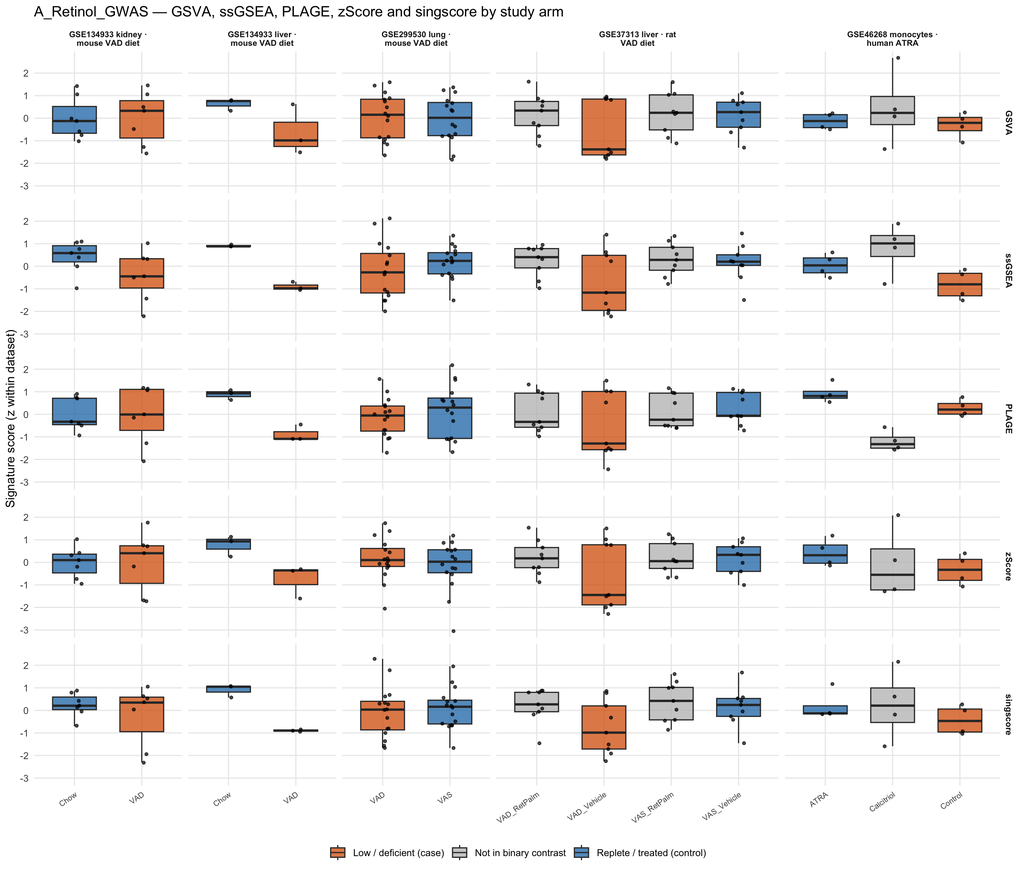

**ANOVA p-values.** *All arms* = one-way ANOVA across every study arm; *case vs control* = group effect after the listed covariates.

| Dataset | Role | Adjusted for | p (all arms) / p (case vs control) GSVA | p (all arms) / p (case vs control) ssGSEA | p (all arms) / p (case vs control) PLAGE | p (all arms) / p (case vs control) zScore | p (all arms) / p (case vs control) singscore |
| --- | --- | --- | --- | --- | --- | --- | --- |
| GSE134933 kidney · mouse VAD diet | External | genotype | 0.992 / 0.988 | 0.125 / 0.127 | 0.948 / 0.905 | 0.981 / 0.980 | 0.408 / 0.392 |
| GSE134933 liver · mouse VAD diet | External | — | 0.132 / 0.132 | 9.0e-05 / 9.0e-05 | 0.002 / 0.002 | 0.039 / 0.039 | 4.2e-04 / 4.2e-04 |
| GSE299530 lung · mouse VAD diet | Training | timepoint, batch | 0.773 / 0.772 | 0.322 / 0.319 | 0.437 / 0.220 | 0.412 / 0.427 | 0.675 / 0.684 |
| GSE37313 liver · rat VAD diet | External | surgery | 0.393 / 0.053 | 0.102 / 0.025 | 0.416 / 0.009 | 0.293 / 0.042 | 0.055 / 0.029 |
| GSE46268 monocytes · human ATRA | External | donor | 0.582 / 0.723 | 0.058 / 0.189 | 1.6e-04 / 0.073 | 0.605 / 0.279 | 0.619 / 0.358 |

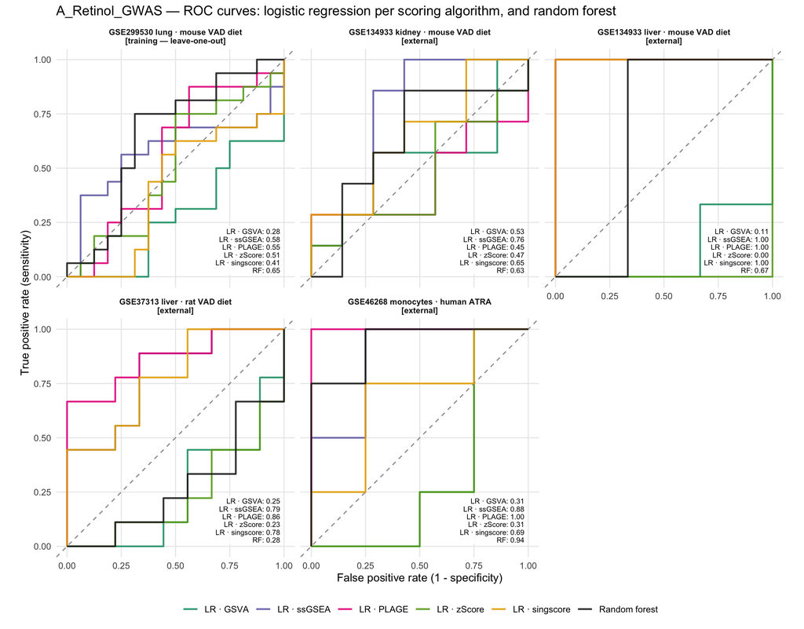

| Dataset | Validation | Model | AUC | 95% CI | Accuracy (p ≥ 0.5) | n case | n control |
| --- | --- | --- | --- | --- | --- | --- | --- |
| GSE299530 lung · mouse VAD diet | Internal (in-sample) | Score · GSVA | 0.50 | 0.29–0.71 | — | 16 | 16 |
|  |  | Score · ssGSEA | 0.62 | 0.41–0.83 | — | 16 | 16 |
|  |  | Score · PLAGE | 0.61 | 0.40–0.81 | — | 16 | 16 |
|  |  | Score · zScore | 0.57 | 0.36–0.77 | — | 16 | 16 |
|  |  | Score · singscore | 0.56 | 0.35–0.77 | — | 16 | 16 |
|  | Internal (LOOCV) | LR · GSVA | 0.28 | 0.10–0.46 | 0.34 | 16 | 16 |
|  |  | LR · ssGSEA | 0.58 | 0.37–0.80 | 0.59 | 16 | 16 |
|  |  | LR · PLAGE | 0.55 | 0.34–0.77 | 0.62 | 16 | 16 |
|  |  | LR · zScore | 0.51 | 0.30–0.72 | 0.53 | 16 | 16 |
|  |  | LR · singscore | 0.41 | 0.20–0.62 | 0.5 | 16 | 16 |
|  |  | Random forest | 0.65 | 0.45–0.86 | 0.72 | 16 | 16 |
|  | Internal (leave-pair-out) | LR · GSVA | 0.36 | — | — | 16 | 16 |
|  |  | LR · ssGSEA | 0.62 | — | — | 16 | 16 |
|  |  | LR · PLAGE | 0.61 | — | — | 16 | 16 |
|  |  | LR · zScore | 0.56 | — | — | 16 | 16 |
|  |  | LR · singscore | 0.51 | — | — | 16 | 16 |
|  |  | Random forest | 0.66 | — | — | 16 | 16 |
| GSE134933 kidney · mouse VAD diet | External | Score · GSVA | 0.53 | 0.19–0.87 | — | 7 | 7 |
|  |  | Score · ssGSEA | 0.76 | 0.46–1.00 | — | 7 | 7 |
|  |  | Score · PLAGE | 0.45 | 0.10–0.79 | — | 7 | 7 |
|  |  | Score · zScore | 0.47 | 0.13–0.81 | — | 7 | 7 |
|  |  | Score · singscore | 0.65 | 0.34–0.96 | — | 7 | 7 |
|  |  | LR · GSVA | 0.53 | 0.19–0.87 | 0.5 | 7 | 7 |
|  |  | LR · ssGSEA | 0.76 | 0.46–1.00 | 0.64 | 7 | 7 |
|  |  | LR · PLAGE | 0.45 | 0.10–0.79 | 0.36 | 7 | 7 |
|  |  | LR · zScore | 0.47 | 0.13–0.81 | 0.57 | 7 | 7 |
|  |  | LR · singscore | 0.65 | 0.34–0.96 | 0.5 | 7 | 7 |
|  |  | Random forest | 0.63 | 0.30–0.97 | 0.64 | 7 | 7 |
| GSE134933 liver · mouse VAD diet |  | Score · GSVA | 0.11 | 0.00–0.42 | — | 3 | 3 |
|  |  | Score · ssGSEA | 1.00 | 1.00–1.00 | — | 3 | 3 |
|  |  | Score · PLAGE | 1.00 | 1.00–1.00 | — | 3 | 3 |
|  |  | Score · zScore | 0.00 | 0.00–0.00 | — | 3 | 3 |
|  |  | Score · singscore | 1.00 | 1.00–1.00 | — | 3 | 3 |
|  |  | LR · GSVA | 0.11 | 0.00–0.42 | 0.17 | 3 | 3 |
|  |  | LR · ssGSEA | 1.00 | 1.00–1.00 | 1 | 3 | 3 |
|  |  | LR · PLAGE | 1.00 | 1.00–1.00 | 1 | 3 | 3 |
|  |  | LR · zScore | 0.00 | 0.00–0.00 | 0 | 3 | 3 |
|  |  | LR · singscore | 1.00 | 1.00–1.00 | 1 | 3 | 3 |
|  |  | Random forest | 0.67 | 0.01–1.00 | 0.83 | 3 | 3 |
| GSE37313 liver · rat VAD diet |  | Score · GSVA | 0.25 | 0.01–0.48 | — | 9 | 9 |
|  |  | Score · ssGSEA | 0.79 | 0.57–1.00 | — | 9 | 9 |
|  |  | Score · PLAGE | 0.86 | 0.69–1.00 | — | 9 | 9 |
|  |  | Score · zScore | 0.23 | 0.01–0.46 | — | 9 | 9 |
|  |  | Score · singscore | 0.78 | 0.56–1.00 | — | 9 | 9 |
|  |  | LR · GSVA | 0.25 | 0.01–0.48 | 0.33 | 9 | 9 |
|  |  | LR · ssGSEA | 0.79 | 0.57–1.00 | 0.67 | 9 | 9 |
|  |  | LR · PLAGE | 0.86 | 0.69–1.00 | 0.78 | 9 | 9 |
|  |  | LR · zScore | 0.23 | 0.01–0.46 | 0.33 | 9 | 9 |
|  |  | LR · singscore | 0.78 | 0.56–1.00 | 0.72 | 9 | 9 |
|  |  | Random forest | 0.28 | 0.03–0.52 | 0.39 | 9 | 9 |
| GSE46268 monocytes · human ATRA |  | Score · GSVA | 0.31 | 0.00–0.79 | — | 4 | 4 |
|  |  | Score · ssGSEA | 0.88 | 0.59–1.00 | — | 4 | 4 |
|  |  | Score · PLAGE | 1.00 | 1.00–1.00 | — | 4 | 4 |
|  |  | Score · zScore | 0.31 | 0.00–0.79 | — | 4 | 4 |
|  |  | Score · singscore | 0.69 | 0.25–1.00 | — | 4 | 4 |
|  |  | LR · GSVA | 0.31 | 0.00–0.79 | 0.38 | 4 | 4 |
|  |  | LR · ssGSEA | 0.88 | 0.59–1.00 | 0.88 | 4 | 4 |
|  |  | LR · PLAGE | 1.00 | 1.00–1.00 | 0.88 | 4 | 4 |
|  |  | LR · zScore | 0.31 | 0.00–0.79 | 0.25 | 4 | 4 |
|  |  | LR · singscore | 0.69 | 0.25–1.00 | 0.75 | 4 | 4 |
|  |  | Random forest | 0.94 | 0.76–1.00 | 0.75 | 4 | 4 |

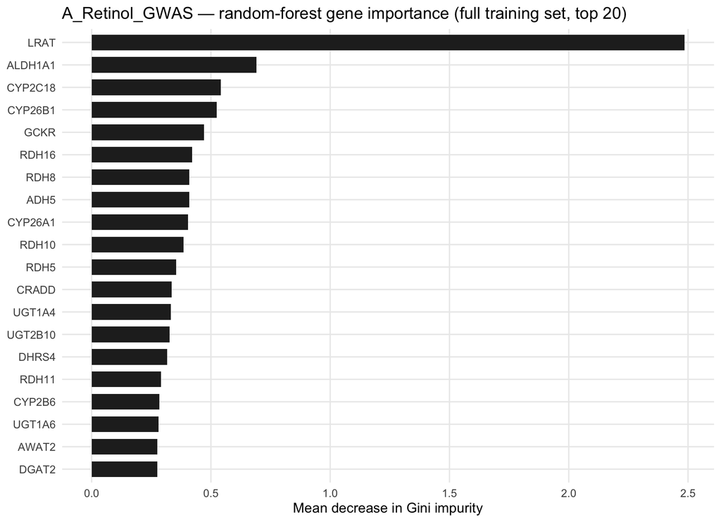

## A_Retinol_MSigDB_Filtered

*Source:* Curated (Signatures/NutSignaturesList.R)

*Panel:* Vitamin A · *Training set:* GSE299530 lung · mouse VAD diet · *Signature size:* 15 genes · *Score direction learned in training:* GSVA higher in case; ssGSEA lower in case; PLAGE higher in case; zScore higher in case; singscore lower in case

| Dataset | Species | Signature genes | Found in data | Coverage |
| --- | --- | --- | --- | --- |
| GSE134933 kidney · mouse VAD diet | Mus musculus | 15 | 12 | 80% |
| GSE134933 liver · mouse VAD diet | Mus musculus | 15 | 12 | 80% |
| GSE299530 lung · mouse VAD diet | Mus musculus | 15 | 14 | 93% |
| GSE37313 liver · rat VAD diet | Rattus norvegicus | 15 | 6 | 40% |
| GSE46268 monocytes · human ATRA | Homo sapiens | 15 | 12 | 80% |

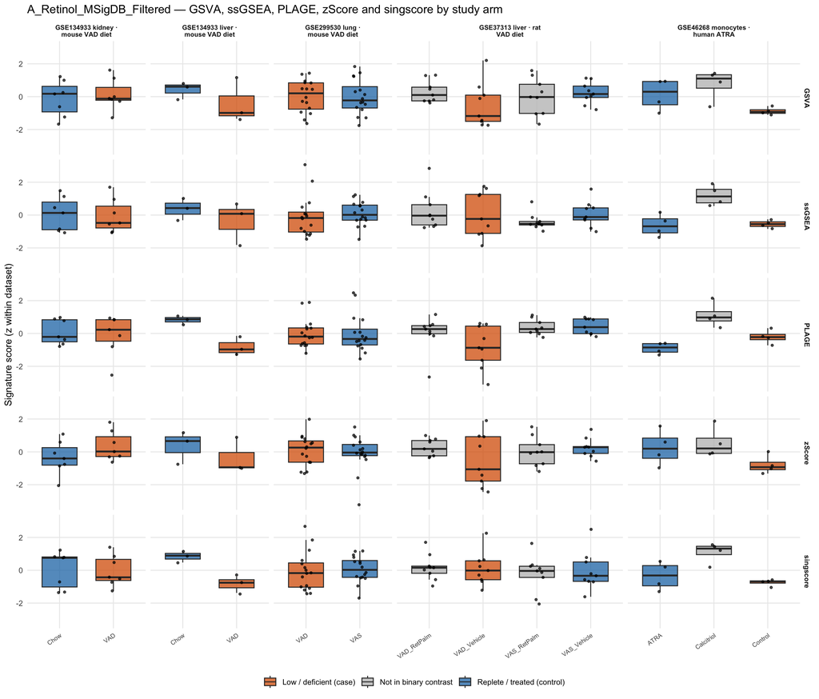

**ANOVA p-values.** *All arms* = one-way ANOVA across every study arm; *case vs control* = group effect after the listed covariates.

| Dataset | Role | Adjusted for | p (all arms) / p (case vs control) GSVA | p (all arms) / p (case vs control) ssGSEA | p (all arms) / p (case vs control) PLAGE | p (all arms) / p (case vs control) zScore | p (all arms) / p (case vs control) singscore |
| --- | --- | --- | --- | --- | --- | --- | --- |
| GSE134933 kidney · mouse VAD diet | External | genotype | 0.654 / 0.499 | 0.866 / 0.738 | 0.749 / 0.618 | 0.197 / 0.180 | 0.918 / 0.858 |
| GSE134933 liver · mouse VAD diet | External | — | 0.363 / 0.363 | 0.414 / 0.414 | 0.013 / 0.013 | 0.440 / 0.440 | 0.009 / 0.009 |
| GSE299530 lung · mouse VAD diet | Training | timepoint, batch | 0.883 / 0.886 | 0.644 / 0.653 | 0.965 / 0.955 | 0.639 / 0.648 | 0.752 / 0.759 |
| GSE37313 liver · rat VAD diet | External | surgery | 0.291 / 0.076 | 0.570 / 0.958 | 0.023 / 0.006 | 0.297 / 0.055 | 0.844 / 0.748 |
| GSE46268 monocytes · human ATRA | External | donor | 0.046 / 0.159 | 0.002 / 0.832 | 0.002 / 0.066 | 0.141 / 0.101 | 0.006 / 0.413 |

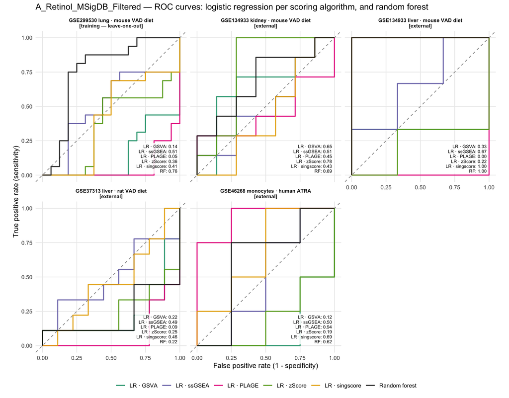

| Dataset | Validation | Model | AUC | 95% CI | Accuracy (p ≥ 0.5) | n case | n control |
| --- | --- | --- | --- | --- | --- | --- | --- |
| GSE299530 lung · mouse VAD diet | Internal (in-sample) | Score · GSVA | 0.52 | 0.31–0.73 | — | 16 | 16 |
|  |  | Score · ssGSEA | 0.61 | 0.40–0.81 | — | 16 | 16 |
|  |  | Score · PLAGE | 0.50 | 0.29–0.71 | — | 16 | 16 |
|  |  | Score · zScore | 0.52 | 0.30–0.73 | — | 16 | 16 |
|  |  | Score · singscore | 0.56 | 0.35–0.77 | — | 16 | 16 |
|  | Internal (LOOCV) | LR · GSVA | 0.14 | 0.02–0.27 | 0.28 | 16 | 16 |
|  |  | LR · ssGSEA | 0.51 | 0.29–0.72 | 0.56 | 16 | 16 |
|  |  | LR · PLAGE | 0.05 | 0.00–0.13 | 0.19 | 16 | 16 |
|  |  | LR · zScore | 0.36 | 0.16–0.57 | 0.56 | 16 | 16 |
|  |  | LR · singscore | 0.41 | 0.20–0.63 | 0.56 | 16 | 16 |
|  |  | Random forest | 0.76 | 0.58–0.95 | 0.75 | 16 | 16 |
|  | Internal (leave-pair-out) | LR · GSVA | 0.21 | — | — | 16 | 16 |
|  |  | LR · ssGSEA | 0.60 | — | — | 16 | 16 |
|  |  | LR · PLAGE | 0.09 | — | — | 16 | 16 |
|  |  | LR · zScore | 0.47 | — | — | 16 | 16 |
|  |  | LR · singscore | 0.47 | — | — | 16 | 16 |
|  |  | Random forest | 0.77 | — | — | 16 | 16 |
| GSE134933 kidney · mouse VAD diet | External | Score · GSVA | 0.65 | 0.33–0.98 | — | 7 | 7 |
|  |  | Score · ssGSEA | 0.51 | 0.18–0.84 | — | 7 | 7 |
|  |  | Score · PLAGE | 0.45 | 0.10–0.79 | — | 7 | 7 |
|  |  | Score · zScore | 0.78 | 0.48–1.00 | — | 7 | 7 |
|  |  | Score · singscore | 0.43 | 0.09–0.76 | — | 7 | 7 |
|  |  | LR · GSVA | 0.65 | 0.33–0.98 | 0.57 | 7 | 7 |
|  |  | LR · ssGSEA | 0.51 | 0.18–0.84 | 0.5 | 7 | 7 |
|  |  | LR · PLAGE | 0.45 | 0.10–0.79 | 0.36 | 7 | 7 |
|  |  | LR · zScore | 0.78 | 0.48–1.00 | 0.64 | 7 | 7 |
|  |  | LR · singscore | 0.43 | 0.09–0.76 | 0.43 | 7 | 7 |
|  |  | Random forest | 0.69 | 0.40–0.99 | 0.64 | 7 | 7 |
| GSE134933 liver · mouse VAD diet |  | Score · GSVA | 0.33 | 0.00–0.99 | — | 3 | 3 |
|  |  | Score · ssGSEA | 0.67 | 0.13–1.00 | — | 3 | 3 |
|  |  | Score · PLAGE | 0.00 | 0.00–0.00 | — | 3 | 3 |
|  |  | Score · zScore | 0.22 | 0.00–0.71 | — | 3 | 3 |
|  |  | Score · singscore | 1.00 | 1.00–1.00 | — | 3 | 3 |
|  |  | LR · GSVA | 0.33 | 0.00–0.99 | 0.33 | 3 | 3 |
|  |  | LR · ssGSEA | 0.67 | 0.13–1.00 | 0.5 | 3 | 3 |
|  |  | LR · PLAGE | 0.00 | 0.00–0.00 | 0 | 3 | 3 |
|  |  | LR · zScore | 0.22 | 0.00–0.71 | 0.33 | 3 | 3 |
|  |  | LR · singscore | 1.00 | 1.00–1.00 | 1 | 3 | 3 |
|  |  | Random forest | 1.00 | 1.00–1.00 | 0.83 | 3 | 3 |
| GSE37313 liver · rat VAD diet |  | Score · GSVA | 0.22 | 0.00–0.47 | — | 9 | 9 |
|  |  | Score · ssGSEA | 0.49 | 0.20–0.78 | — | 9 | 9 |
|  |  | Score · PLAGE | 0.09 | 0.00–0.22 | — | 9 | 9 |
|  |  | Score · zScore | 0.25 | 0.00–0.49 | — | 9 | 9 |
|  |  | Score · singscore | 0.46 | 0.17–0.74 | — | 9 | 9 |
|  |  | LR · GSVA | 0.22 | 0.00–0.47 | 0.28 | 9 | 9 |
|  |  | LR · ssGSEA | 0.49 | 0.20–0.78 | 0.44 | 9 | 9 |
|  |  | LR · PLAGE | 0.09 | 0.00–0.22 | 0.28 | 9 | 9 |
|  |  | LR · zScore | 0.25 | 0.00–0.49 | 0.28 | 9 | 9 |
|  |  | LR · singscore | 0.46 | 0.17–0.74 | 0.44 | 9 | 9 |
|  |  | Random forest | 0.22 | 0.00–0.47 | 0.28 | 9 | 9 |
| GSE46268 monocytes · human ATRA |  | Score · GSVA | 0.12 | 0.00–0.41 | — | 4 | 4 |
|  |  | Score · ssGSEA | 0.50 | 0.01–0.99 | — | 4 | 4 |
|  |  | Score · PLAGE | 0.94 | 0.76–1.00 | — | 4 | 4 |
|  |  | Score · zScore | 0.19 | 0.00–0.52 | — | 4 | 4 |
|  |  | Score · singscore | 0.69 | 0.25–1.00 | — | 4 | 4 |
|  |  | LR · GSVA | 0.12 | 0.00–0.41 | 0.25 | 4 | 4 |
|  |  | LR · ssGSEA | 0.50 | 0.01–0.99 | 0.38 | 4 | 4 |
|  |  | LR · PLAGE | 0.94 | 0.76–1.00 | 0.88 | 4 | 4 |
|  |  | LR · zScore | 0.19 | 0.00–0.52 | 0.25 | 4 | 4 |
|  |  | LR · singscore | 0.69 | 0.25–1.00 | 0.62 | 4 | 4 |
|  |  | Random forest | 0.62 | 0.14–1.00 | 0.62 | 4 | 4 |

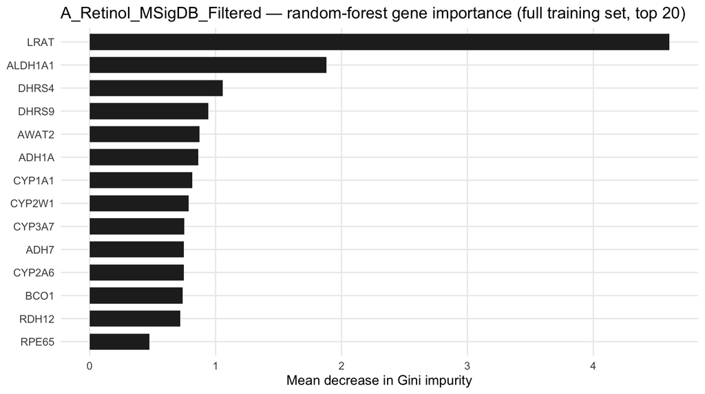

## A_Retinol_GLM_43

*Source:* Curated (Signatures/NutSignaturesList.R)

| Dataset | Species | Signature genes | Found in data | Coverage |
| --- | --- | --- | --- | --- |
| GSE134933 kidney · mouse VAD diet | Mus musculus | 42 | 39 | 93% |
| GSE134933 liver · mouse VAD diet | Mus musculus | 42 | 37 | 88% |
| GSE299530 lung · mouse VAD diet | Mus musculus | 42 | 38 | 90% |
| GSE37313 liver · rat VAD diet | Rattus norvegicus | 42 | 20 | 48% |
| GSE46268 monocytes · human ATRA | Homo sapiens | 42 | 40 | 95% |

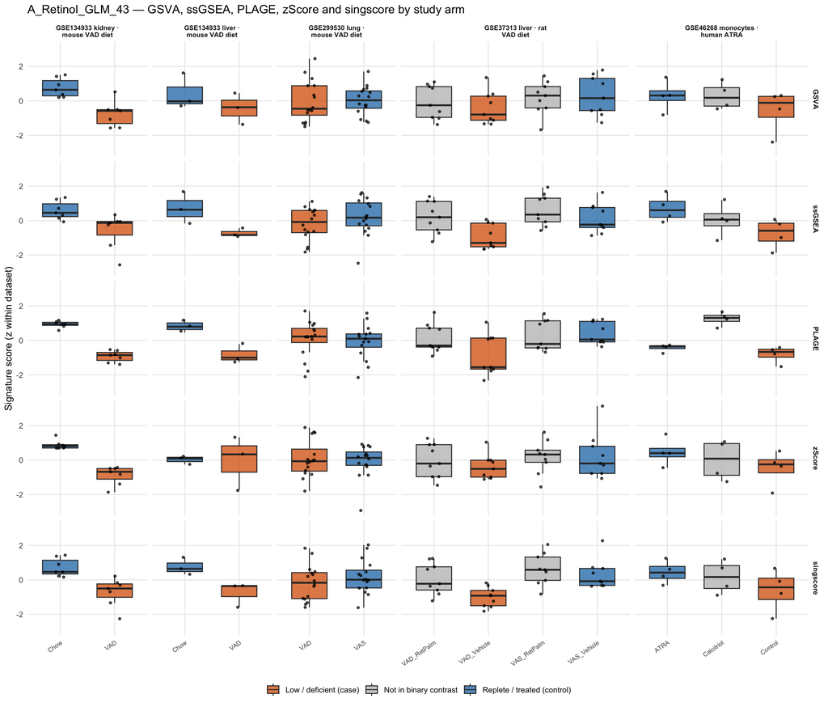

**ANOVA p-values.** *All arms* = one-way ANOVA across every study arm; *case vs control* = group effect after the listed covariates.

| Dataset | Role | Adjusted for | p (all arms) / p (case vs control) GSVA | p (all arms) / p (case vs control) ssGSEA | p (all arms) / p (case vs control) PLAGE | p (all arms) / p (case vs control) zScore | p (all arms) / p (case vs control) singscore |
| --- | --- | --- | --- | --- | --- | --- | --- |
| GSE134933 kidney · mouse VAD diet | Training | genotype | 8.9e-04 / 2.6e-05 | 0.020 / 0.007 | 2.1e-08 / 8.5e-08 | 5.8e-06 / 1.0e-05 | 0.002 / 3.0e-04 |
| GSE134933 liver · mouse VAD diet | External | — | 0.342 / 0.342 | 0.062 / 0.062 | 0.013 / 0.013 | 0.959 / 0.959 | 0.039 / 0.039 |
| GSE299530 lung · mouse VAD diet | External | timepoint, batch | 0.897 / 0.891 | 0.262 / 0.153 | 0.716 / 0.596 | 0.658 / 0.654 | 0.327 / 0.256 |
| GSE37313 liver · rat VAD diet | External | surgery | 0.459 / 0.032 | 0.004 / 2.9e-06 | 0.027 / 9.0e-06 | 0.524 / 0.112 | 0.001 / 2.0e-05 |
| GSE46268 monocytes · human ATRA | External | donor | 0.405 / 0.341 | 0.113 / 0.099 | 7.2e-05 / 0.222 | 0.456 / 0.255 | 0.332 / 0.308 |

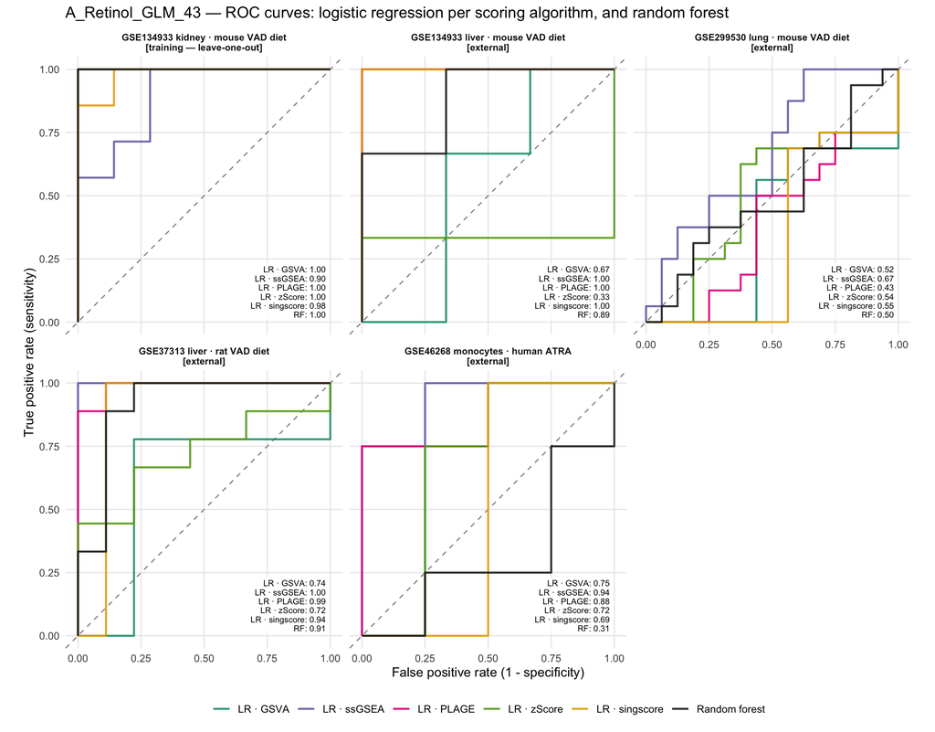

| Dataset | Validation | Model | AUC | 95% CI | Accuracy (p ≥ 0.5) | n case | n control |
| --- | --- | --- | --- | --- | --- | --- | --- |
| GSE134933 kidney · mouse VAD diet | Internal (in-sample) | Score · GSVA | 1.00 | 1.00–1.00 | — | 7 | 7 |
|  |  | Score · ssGSEA | 0.94 | 0.82–1.00 | — | 7 | 7 |
|  |  | Score · PLAGE | 1.00 | 1.00–1.00 | — | 7 | 7 |
|  |  | Score · zScore | 1.00 | 1.00–1.00 | — | 7 | 7 |
|  |  | Score · singscore | 1.00 | 1.00–1.00 | — | 7 | 7 |
|  | Internal (LOOCV) | LR · GSVA | 1.00 | 1.00–1.00 | 1 | 7 | 7 |
|  |  | LR · ssGSEA | 0.90 | 0.73–1.00 | 0.79 | 7 | 7 |
|  |  | LR · PLAGE | 1.00 | 1.00–1.00 | 1 | 7 | 7 |
|  |  | LR · zScore | 1.00 | 1.00–1.00 | 1 | 7 | 7 |
|  |  | LR · singscore | 0.98 | 0.92–1.00 | 0.86 | 7 | 7 |
|  |  | Random forest | 1.00 | 1.00–1.00 | 1 | 7 | 7 |
|  | Internal (leave-pair-out) | LR · GSVA | 1.00 | — | — | 7 | 7 |
|  |  | LR · ssGSEA | 0.94 | — | — | 7 | 7 |
|  |  | LR · PLAGE | 1.00 | — | — | 7 | 7 |
|  |  | LR · zScore | 1.00 | — | — | 7 | 7 |
|  |  | LR · singscore | 1.00 | — | — | 7 | 7 |
|  |  | Random forest | 1.00 | — | — | 7 | 7 |
| GSE134933 liver · mouse VAD diet | External | Score · GSVA | 0.78 | 0.29–1.00 | — | 3 | 3 |
|  |  | Score · ssGSEA | 1.00 | 1.00–1.00 | — | 3 | 3 |
|  |  | Score · PLAGE | 1.00 | 1.00–1.00 | — | 3 | 3 |
|  |  | Score · zScore | 0.33 | 0.00–0.99 | — | 3 | 3 |
|  |  | Score · singscore | 1.00 | 1.00–1.00 | — | 3 | 3 |
|  |  | LR · GSVA | 0.67 | 0.17–1.00 | 0.5 | 3 | 3 |
|  |  | LR · ssGSEA | 1.00 | 1.00–1.00 | 0.83 | 3 | 3 |
|  |  | LR · PLAGE | 1.00 | 1.00–1.00 | 1 | 3 | 3 |
|  |  | LR · zScore | 0.33 | 0.00–0.99 | 0.33 | 3 | 3 |
|  |  | LR · singscore | 1.00 | 1.00–1.00 | 0.83 | 3 | 3 |
|  |  | Random forest | 0.89 | 0.58–1.00 | 0.83 | 3 | 3 |
| GSE299530 lung · mouse VAD diet |  | Score · GSVA | 0.59 | 0.37–0.81 | — | 16 | 16 |
|  |  | Score · ssGSEA | 0.67 | 0.47–0.86 | — | 16 | 16 |
|  |  | Score · PLAGE | 0.43 | 0.22–0.64 | — | 16 | 16 |
|  |  | Score · zScore | 0.52 | 0.30–0.73 | — | 16 | 16 |
|  |  | Score · singscore | 0.63 | 0.43–0.84 | — | 16 | 16 |
|  |  | LR · GSVA | 0.52 | 0.33–0.71 | 0.56 | 16 | 16 |
|  |  | LR · ssGSEA | 0.67 | 0.47–0.86 | 0.56 | 16 | 16 |
|  |  | LR · PLAGE | 0.43 | 0.22–0.63 | 0.47 | 16 | 16 |
|  |  | LR · zScore | 0.54 | 0.33–0.74 | 0.62 | 16 | 16 |
|  |  | LR · singscore | 0.55 | 0.38–0.73 | 0.5 | 16 | 16 |
|  |  | Random forest | 0.50 | 0.29–0.71 | 0.44 | 16 | 16 |
| GSE37313 liver · rat VAD diet |  | Score · GSVA | 0.80 | 0.59–1.00 | — | 9 | 9 |
|  |  | Score · ssGSEA | 1.00 | 1.00–1.00 | — | 9 | 9 |
|  |  | Score · PLAGE | 0.99 | 0.95–1.00 | — | 9 | 9 |
|  |  | Score · zScore | 0.73 | 0.48–0.98 | — | 9 | 9 |
|  |  | Score · singscore | 1.00 | 1.00–1.00 | — | 9 | 9 |
|  |  | LR · GSVA | 0.74 | 0.51–0.98 | 0.72 | 9 | 9 |
|  |  | LR · ssGSEA | 1.00 | 1.00–1.00 | 0.89 | 9 | 9 |
|  |  | LR · PLAGE | 0.99 | 0.95–1.00 | 0.89 | 9 | 9 |
|  |  | LR · zScore | 0.72 | 0.47–0.98 | 0.61 | 9 | 9 |
|  |  | LR · singscore | 0.94 | 0.84–1.00 | 0.94 | 9 | 9 |
|  |  | Random forest | 0.91 | 0.76–1.00 | 0.89 | 9 | 9 |
| GSE46268 monocytes · human ATRA |  | Score · GSVA | 0.81 | 0.48–1.00 | — | 4 | 4 |
|  |  | Score · ssGSEA | 0.94 | 0.76–1.00 | — | 4 | 4 |
|  |  | Score · PLAGE | 0.88 | 0.59–1.00 | — | 4 | 4 |
|  |  | Score · zScore | 0.75 | 0.35–1.00 | — | 4 | 4 |
|  |  | Score · singscore | 0.75 | 0.35–1.00 | — | 4 | 4 |
|  |  | LR · GSVA | 0.75 | 0.36–1.00 | 0.62 | 4 | 4 |
|  |  | LR · ssGSEA | 0.94 | 0.76–1.00 | 0.88 | 4 | 4 |
|  |  | LR · PLAGE | 0.88 | 0.59–1.00 | 0.62 | 4 | 4 |
|  |  | LR · zScore | 0.72 | 0.29–1.00 | 0.75 | 4 | 4 |
|  |  | LR · singscore | 0.69 | 0.31–1.00 | 0.75 | 4 | 4 |
|  |  | Random forest | 0.31 | 0.00–0.75 | 0.25 | 4 | 4 |

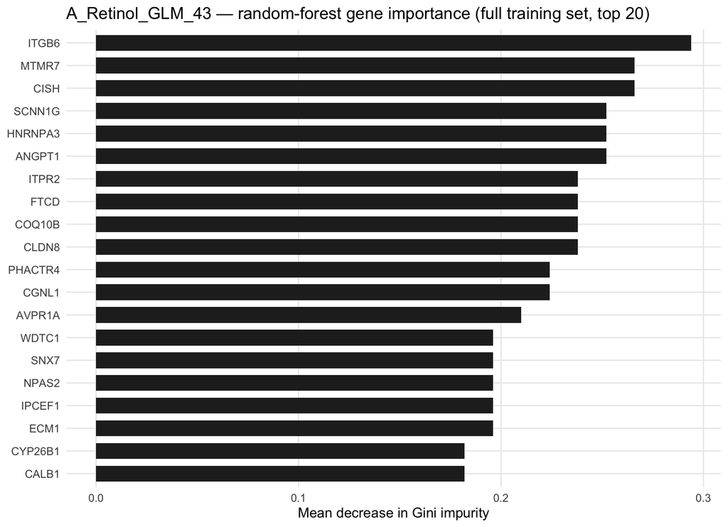

## A_Retinol_Quiles_20

*Source:* Curated (Signatures/NutSignaturesList.R)

*Panel:* Vitamin A · *Training set:* GSE299530 lung · mouse VAD diet · *Signature size:* 20 genes · *Score direction learned in training:* GSVA lower in case; ssGSEA lower in case; PLAGE lower in case; zScore lower in case; singscore lower in case

| Dataset | Species | Signature genes | Found in data | Coverage |
| --- | --- | --- | --- | --- |
| GSE134933 kidney · mouse VAD diet | Mus musculus | 20 | 18 | 90% |
| GSE134933 liver · mouse VAD diet | Mus musculus | 20 | 15 | 75% |
| GSE299530 lung · mouse VAD diet | Mus musculus | 20 | 18 | 90% |
| GSE37313 liver · rat VAD diet | Rattus norvegicus | 20 | 6 | 30% |
| GSE46268 monocytes · human ATRA | Homo sapiens | 20 | 18 | 90% |

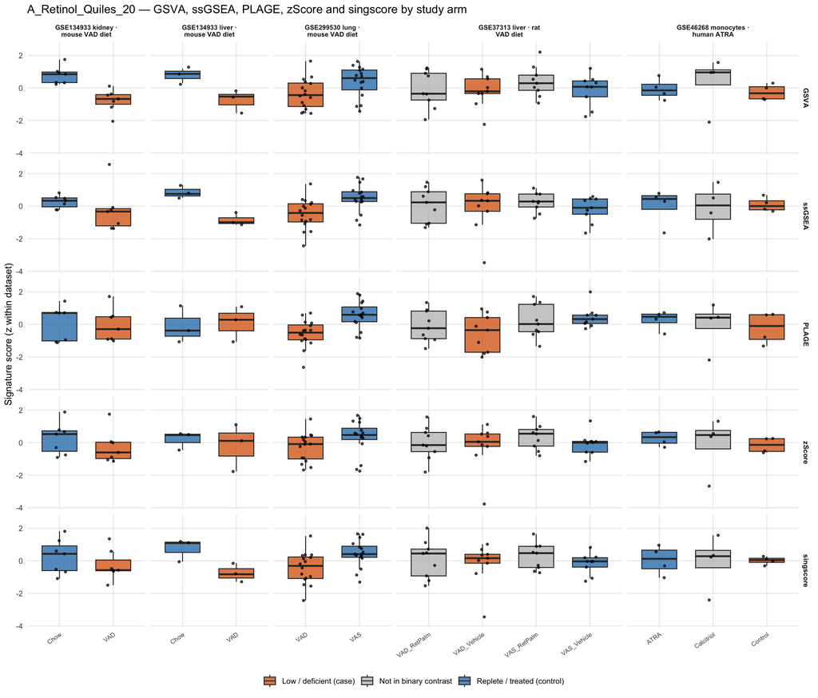

**ANOVA p-values.** *All arms* = one-way ANOVA across every study arm; *case vs control* = group effect after the listed covariates.

| Dataset | Role | Adjusted for | p (all arms) / p (case vs control) GSVA | p (all arms) / p (case vs control) ssGSEA | p (all arms) / p (case vs control) PLAGE | p (all arms) / p (case vs control) zScore | p (all arms) / p (case vs control) singscore |
| --- | --- | --- | --- | --- | --- | --- | --- |
| GSE134933 kidney · mouse VAD diet | External | genotype | 5.2e-04 / 8.9e-04 | 0.339 / 0.326 | 0.825 / 0.640 | 0.331 / 0.143 | 0.353 / 0.182 |
| GSE134933 liver · mouse VAD diet | External | — | 0.030 / 0.030 | 0.006 / 0.006 | 0.835 / 0.835 | 0.686 / 0.686 | 0.045 / 0.045 |
| GSE299530 lung · mouse VAD diet | Training | timepoint, batch | 0.031 / 0.010 | 0.004 / 0.001 | 4.7e-04 / 3.2e-04 | 0.095 / 0.048 | 0.009 / 0.002 |
| GSE37313 liver · rat VAD diet | External | surgery | 0.610 / 0.913 | 0.808 / 0.875 | 0.173 / 0.043 | 0.650 / 0.755 | 0.746 / 0.974 |
| GSE46268 monocytes · human ATRA | External | donor | 0.718 / 0.464 | 0.964 / 0.873 | 0.815 / 0.308 | 0.841 / 0.004 | 0.989 / 0.947 |

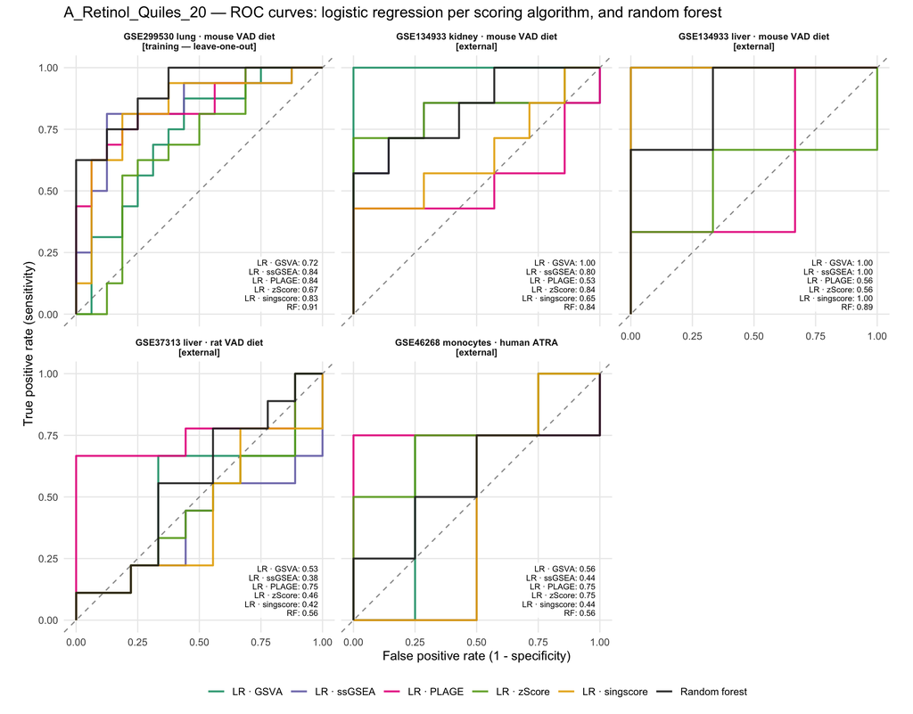

| Dataset | Validation | Model | AUC | 95% CI | Accuracy (p ≥ 0.5) | n case | n control |
| --- | --- | --- | --- | --- | --- | --- | --- |
| GSE299530 lung · mouse VAD diet | Internal (in-sample) | Score · GSVA | 0.75 | 0.58–0.92 | — | 16 | 16 |
|  |  | Score · ssGSEA | 0.86 | 0.73–0.99 | — | 16 | 16 |
|  |  | Score · PLAGE | 0.89 | 0.77–1.00 | — | 16 | 16 |
|  |  | Score · zScore | 0.70 | 0.51–0.89 | — | 16 | 16 |
|  |  | Score · singscore | 0.85 | 0.71–0.99 | — | 16 | 16 |
|  | Internal (LOOCV) | LR · GSVA | 0.72 | 0.53–0.90 | 0.66 | 16 | 16 |
|  |  | LR · ssGSEA | 0.84 | 0.69–0.99 | 0.75 | 16 | 16 |
|  |  | LR · PLAGE | 0.84 | 0.70–0.98 | 0.78 | 16 | 16 |
|  |  | LR · zScore | 0.67 | 0.47–0.87 | 0.62 | 16 | 16 |
|  |  | LR · singscore | 0.83 | 0.68–0.99 | 0.75 | 16 | 16 |
|  |  | Random forest | 0.91 | 0.81–1.00 | 0.78 | 16 | 16 |
|  | Internal (leave-pair-out) | LR · GSVA | 0.75 | — | — | 16 | 16 |
|  |  | LR · ssGSEA | 0.86 | — | — | 16 | 16 |
|  |  | LR · PLAGE | 0.89 | — | — | 16 | 16 |
|  |  | LR · zScore | 0.70 | — | — | 16 | 16 |
|  |  | LR · singscore | 0.85 | — | — | 16 | 16 |
|  |  | Random forest | 0.93 | — | — | 16 | 16 |
| GSE134933 kidney · mouse VAD diet | External | Score · GSVA | 1.00 | 1.00–1.00 | — | 7 | 7 |
|  |  | Score · ssGSEA | 0.80 | 0.51–1.00 | — | 7 | 7 |
|  |  | Score · PLAGE | 0.53 | 0.17–0.89 | — | 7 | 7 |
|  |  | Score · zScore | 0.84 | 0.59–1.00 | — | 7 | 7 |
|  |  | Score · singscore | 0.65 | 0.34–0.97 | — | 7 | 7 |
|  |  | LR · GSVA | 1.00 | 1.00–1.00 | 0.93 | 7 | 7 |
|  |  | LR · ssGSEA | 0.80 | 0.51–1.00 | 0.71 | 7 | 7 |
|  |  | LR · PLAGE | 0.53 | 0.17–0.89 | 0.5 | 7 | 7 |
|  |  | LR · zScore | 0.84 | 0.59–1.00 | 0.79 | 7 | 7 |
|  |  | LR · singscore | 0.65 | 0.34–0.97 | 0.57 | 7 | 7 |
|  |  | Random forest | 0.84 | 0.62–1.00 | 0.71 | 7 | 7 |
| GSE134933 liver · mouse VAD diet |  | Score · GSVA | 1.00 | 1.00–1.00 | — | 3 | 3 |
|  |  | Score · ssGSEA | 1.00 | 1.00–1.00 | — | 3 | 3 |
|  |  | Score · PLAGE | 0.56 | 0.00–1.00 | — | 3 | 3 |
|  |  | Score · zScore | 0.56 | 0.00–1.00 | — | 3 | 3 |
|  |  | Score · singscore | 1.00 | 1.00–1.00 | — | 3 | 3 |
|  |  | LR · GSVA | 1.00 | 1.00–1.00 | 1 | 3 | 3 |
|  |  | LR · ssGSEA | 1.00 | 1.00–1.00 | 1 | 3 | 3 |
|  |  | LR · PLAGE | 0.56 | 0.00–1.00 | 0.33 | 3 | 3 |
|  |  | LR · zScore | 0.56 | 0.00–1.00 | 0.5 | 3 | 3 |
|  |  | LR · singscore | 1.00 | 1.00–1.00 | 1 | 3 | 3 |
|  |  | Random forest | 0.89 | 0.58–1.00 | 0.67 | 3 | 3 |
| GSE37313 liver · rat VAD diet |  | Score · GSVA | 0.53 | 0.23–0.83 | — | 9 | 9 |
|  |  | Score · ssGSEA | 0.38 | 0.10–0.66 | — | 9 | 9 |
|  |  | Score · PLAGE | 0.75 | 0.49–1.00 | — | 9 | 9 |
|  |  | Score · zScore | 0.46 | 0.17–0.74 | — | 9 | 9 |
|  |  | Score · singscore | 0.42 | 0.13–0.71 | — | 9 | 9 |
|  |  | LR · GSVA | 0.53 | 0.23–0.83 | 0.56 | 9 | 9 |
|  |  | LR · ssGSEA | 0.38 | 0.10–0.66 | 0.44 | 9 | 9 |
|  |  | LR · PLAGE | 0.75 | 0.49–1.00 | 0.78 | 9 | 9 |
|  |  | LR · zScore | 0.46 | 0.17–0.74 | 0.5 | 9 | 9 |
|  |  | LR · singscore | 0.42 | 0.13–0.71 | 0.5 | 9 | 9 |
|  |  | Random forest | 0.56 | 0.27–0.84 | 0.5 | 9 | 9 |
| GSE46268 monocytes · human ATRA |  | Score · GSVA | 0.56 | 0.04–1.00 | — | 4 | 4 |
|  |  | Score · ssGSEA | 0.44 | 0.00–0.96 | — | 4 | 4 |
|  |  | Score · PLAGE | 0.75 | 0.26–1.00 | — | 4 | 4 |
|  |  | Score · zScore | 0.75 | 0.35–1.00 | — | 4 | 4 |
|  |  | Score · singscore | 0.44 | 0.00–0.96 | — | 4 | 4 |
|  |  | LR · GSVA | 0.56 | 0.04–1.00 | 0.62 | 4 | 4 |
|  |  | LR · ssGSEA | 0.44 | 0.00–0.96 | 0.5 | 4 | 4 |
|  |  | LR · PLAGE | 0.75 | 0.26–1.00 | 0.62 | 4 | 4 |
|  |  | LR · zScore | 0.75 | 0.35–1.00 | 0.75 | 4 | 4 |
|  |  | LR · singscore | 0.44 | 0.00–0.96 | 0.5 | 4 | 4 |
|  |  | Random forest | 0.56 | 0.08–1.00 | 0.5 | 4 | 4 |

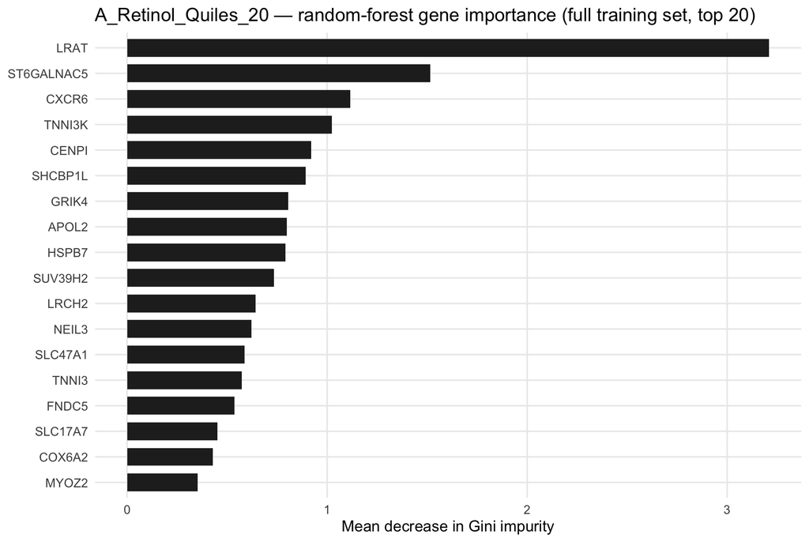

# Vitamin D

## Vitamin_D_Aigner_35

*Source:* Curated (Signatures/NutSignaturesList.R)

*Panel:* Vitamin D · *Training set:* GSE63086 MG63 · human 1,25D · *Signature size:* 35 genes · *Score direction learned in training:* GSVA lower in case; ssGSEA lower in case; PLAGE lower in case; zScore lower in case; singscore lower in case

| Dataset | Species | Signature genes | Found in data | Coverage |
| --- | --- | --- | --- | --- |
| GSE63086 MG63 · human 1,25D | Homo sapiens | 35 | 34 | 97% |
| GSE221690 prostate lines · human 1,25D | Homo sapiens | 35 | 35 | 100% |
| GSE15947 RWPE1 · human 1,25D | Homo sapiens | 35 | 34 | 97% |
| GSE46268 monocytes · human 1,25D | Homo sapiens | 35 | 34 | 97% |
| GSE283020 TH2 · mouse VitD-deficient diet | Mus musculus | 35 | 33 | 94% |

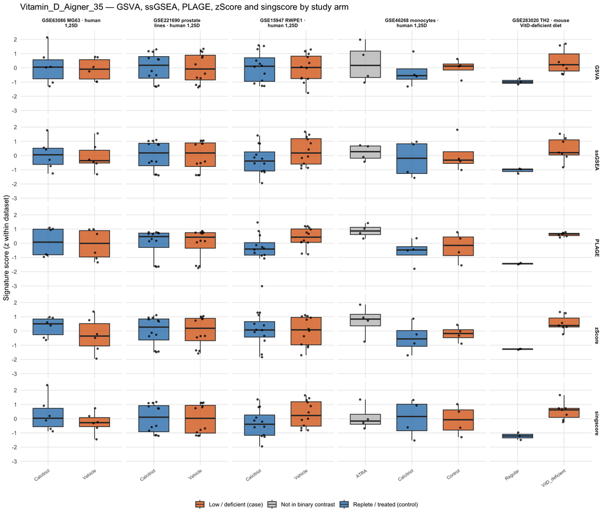

**ANOVA p-values.** *All arms* = one-way ANOVA across every study arm; *case vs control* = group effect after the listed covariates.

| Dataset | Role | Adjusted for | p (all arms) / p (case vs control) GSVA | p (all arms) / p (case vs control) ssGSEA | p (all arms) / p (case vs control) PLAGE | p (all arms) / p (case vs control) zScore | p (all arms) / p (case vs control) singscore |
| --- | --- | --- | --- | --- | --- | --- | --- |
| GSE63086 MG63 · human 1,25D | Training | knockdown | 0.733 / 0.686 | 0.812 / 0.731 | 0.801 / 0.189 | 0.328 / 0.164 | 0.339 / 0.326 |
| GSE221690 prostate lines · human 1,25D | External | cell_line | 0.915 / 0.463 | 0.975 / 0.469 | 0.998 / 0.959 | 0.976 / 0.727 | 0.931 / 0.349 |
| GSE15947 RWPE1 · human 1,25D | External | time | 0.854 / 0.860 | 0.145 / 0.048 | 0.048 / 0.043 | 0.953 / 0.946 | 0.101 / 0.026 |
| GSE46268 monocytes · human 1,25D | External | donor | 0.695 / 0.647 | 0.837 / 0.566 | 0.079 / 0.226 | 0.229 / 0.666 | 0.969 / 0.622 |
| GSE283020 TH2 · mouse VitD-deficient diet | External | batch | 0.030 / 0.006 | 0.016 / 0.006 | 6.1e-09 / 5.9e-08 | 6.0e-04 / 9.5e-05 | 0.002 / 0.002 |

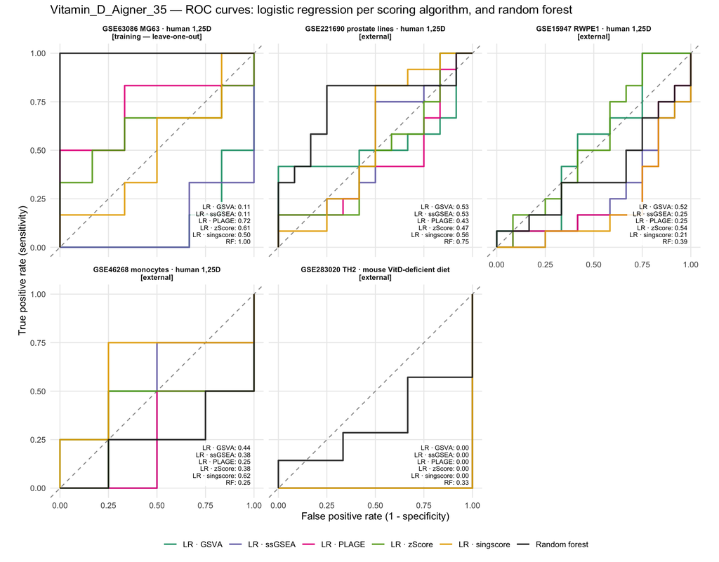

| Dataset | Validation | Model | AUC | 95% CI | Accuracy (p ≥ 0.5) | n case | n control |
| --- | --- | --- | --- | --- | --- | --- | --- |
| GSE63086 MG63 · human 1,25D | Internal (in-sample) | Score · GSVA | 0.47 | 0.08–0.87 | — | 6 | 6 |
|  |  | Score · ssGSEA | 0.53 | 0.15–0.90 | — | 6 | 6 |
|  |  | Score · PLAGE | 0.72 | 0.38–1.00 | — | 6 | 6 |
|  |  | Score · zScore | 0.75 | 0.44–1.00 | — | 6 | 6 |
|  |  | Score · singscore | 0.64 | 0.28–1.00 | — | 6 | 6 |
|  | Internal (LOOCV) | LR · GSVA | 0.11 | 0.00–0.31 | 0.25 | 6 | 6 |
|  |  | LR · ssGSEA | 0.11 | 0.00–0.31 | 0.25 | 6 | 6 |
|  |  | LR · PLAGE | 0.72 | 0.38–1.00 | 0.58 | 6 | 6 |
|  |  | LR · zScore | 0.61 | 0.24–0.98 | 0.67 | 6 | 6 |
|  |  | LR · singscore | 0.50 | 0.13–0.87 | 0.5 | 6 | 6 |
|  |  | Random forest | 1.00 | 1.00–1.00 | 1 | 6 | 6 |
|  | Internal (leave-pair-out) | LR · GSVA | 0.31 | — | — | 6 | 6 |
|  |  | LR · ssGSEA | 0.31 | — | — | 6 | 6 |
|  |  | LR · PLAGE | 0.72 | — | — | 6 | 6 |
|  |  | LR · zScore | 0.75 | — | — | 6 | 6 |
|  |  | LR · singscore | 0.61 | — | — | 6 | 6 |
|  |  | Random forest | 1.00 | — | — | 6 | 6 |
| GSE221690 prostate lines · human 1,25D | External | Score · GSVA | 0.53 | 0.27–0.80 | — | 12 | 12 |
|  |  | Score · ssGSEA | 0.53 | 0.29–0.78 | — | 12 | 12 |
|  |  | Score · PLAGE | 0.43 | 0.18–0.68 | — | 12 | 12 |
|  |  | Score · zScore | 0.47 | 0.22–0.72 | — | 12 | 12 |
|  |  | Score · singscore | 0.56 | 0.30–0.81 | — | 12 | 12 |
|  |  | LR · GSVA | 0.53 | 0.27–0.80 | 0.46 | 12 | 12 |
|  |  | LR · ssGSEA | 0.53 | 0.29–0.78 | 0.54 | 12 | 12 |
|  |  | LR · PLAGE | 0.43 | 0.18–0.68 | 0.38 | 12 | 12 |
|  |  | LR · zScore | 0.47 | 0.22–0.72 | 0.5 | 12 | 12 |
|  |  | LR · singscore | 0.56 | 0.30–0.81 | 0.5 | 12 | 12 |
|  |  | Random forest | 0.75 | 0.53–0.97 | 0.71 | 12 | 12 |
| GSE15947 RWPE1 · human 1,25D |  | Score · GSVA | 0.52 | 0.27–0.77 | — | 12 | 12 |
|  |  | Score · ssGSEA | 0.25 | 0.05–0.45 | — | 12 | 12 |
|  |  | Score · PLAGE | 0.25 | 0.04–0.46 | — | 12 | 12 |
|  |  | Score · zScore | 0.54 | 0.30–0.79 | — | 12 | 12 |
|  |  | Score · singscore | 0.21 | 0.02–0.40 | — | 12 | 12 |
|  |  | LR · GSVA | 0.52 | 0.27–0.77 | 0.54 | 12 | 12 |
|  |  | LR · ssGSEA | 0.25 | 0.05–0.45 | 0.29 | 12 | 12 |
|  |  | LR · PLAGE | 0.25 | 0.04–0.46 | 0.25 | 12 | 12 |
|  |  | LR · zScore | 0.54 | 0.30–0.79 | 0.54 | 12 | 12 |
|  |  | LR · singscore | 0.21 | 0.02–0.40 | 0.25 | 12 | 12 |
|  |  | Random forest | 0.39 | 0.15–0.63 | 0.42 | 12 | 12 |
| GSE46268 monocytes · human 1,25D |  | Score · GSVA | 0.44 | 0.00–0.96 | — | 4 | 4 |
|  |  | Score · ssGSEA | 0.38 | 0.00–0.86 | — | 4 | 4 |
|  |  | Score · PLAGE | 0.25 | 0.00–0.65 | — | 4 | 4 |
|  |  | Score · zScore | 0.38 | 0.00–0.86 | — | 4 | 4 |
|  |  | Score · singscore | 0.62 | 0.14–1.00 | — | 4 | 4 |
|  |  | LR · GSVA | 0.44 | 0.00–0.96 | 0.38 | 4 | 4 |
|  |  | LR · ssGSEA | 0.38 | 0.00–0.86 | 0.5 | 4 | 4 |
|  |  | LR · PLAGE | 0.25 | 0.00–0.65 | 0.5 | 4 | 4 |
|  |  | LR · zScore | 0.38 | 0.00–0.86 | 0.5 | 4 | 4 |
|  |  | LR · singscore | 0.62 | 0.14–1.00 | 0.62 | 4 | 4 |
|  |  | Random forest | 0.25 | 0.00–0.65 | 0.38 | 4 | 4 |
| GSE283020 TH2 · mouse VitD-deficient diet |  | Score · GSVA | 0.00 | 0.00–0.00 | — | 7 | 3 |
|  |  | Score · ssGSEA | 0.00 | 0.00–0.00 | — | 7 | 3 |
|  |  | Score · PLAGE | 0.00 | 0.00–0.00 | — | 7 | 3 |
|  |  | Score · zScore | 0.00 | 0.00–0.00 | — | 7 | 3 |
|  |  | Score · singscore | 0.00 | 0.00–0.00 | — | 7 | 3 |
|  |  | LR · GSVA | 0.00 | 0.00–0.00 | 0.2 | 7 | 3 |
|  |  | LR · ssGSEA | 0.00 | 0.00–0.00 | 0.1 | 7 | 3 |
|  |  | LR · PLAGE | 0.00 | 0.00–0.00 | 0 | 7 | 3 |
|  |  | LR · zScore | 0.00 | 0.00–0.00 | 0.1 | 7 | 3 |
|  |  | LR · singscore | 0.00 | 0.00–0.00 | 0.1 | 7 | 3 |
|  |  | Random forest | 0.33 | 0.00–0.71 | 0.3 | 7 | 3 |

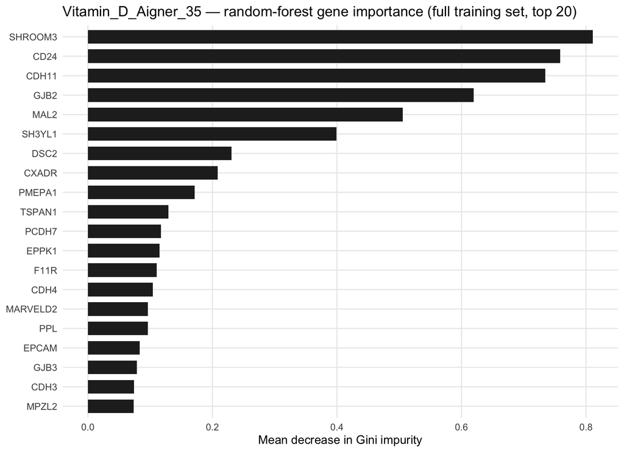

# Vitamin C

## Vitamin_C

*Source:* Curated (Signatures/NutSignaturesList.R)

*Panel:* Vitamin C · *Training set:* GSE233598 liver · mouse Gulo-/- no vitC · *Signature size:* 11 genes · *Score direction learned in training:* GSVA higher in case; ssGSEA lower in case; PLAGE higher in case; zScore higher in case; singscore lower in case

| Dataset | Species | Signature genes | Found in data | Coverage |
| --- | --- | --- | --- | --- |
| GSE233598 liver · mouse Gulo-/- no vitC | Mus musculus | 11 | 11 | 100% |
| GSE190371 kidney · mouse Gulo-/- (pseudobulk) | Mus musculus | 11 | 11 | 100% |
| GSE295923 embryo headfold · mouse Gulo-/- maternal vitC | Mus musculus | 11 | 11 | 100% |

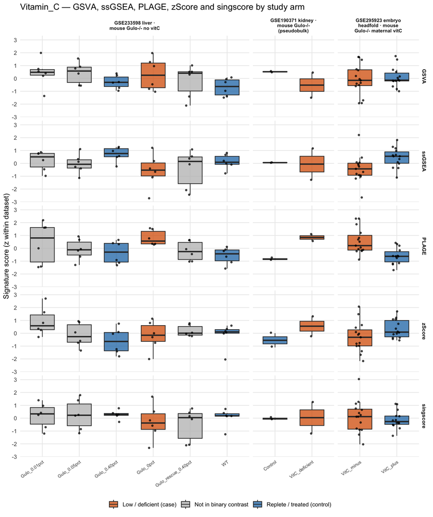

**ANOVA p-values.** *All arms* = one-way ANOVA across every study arm; *case vs control* = group effect after the listed covariates.

| Dataset | Role | Adjusted for | p (all arms) / p (case vs control) GSVA | p (all arms) / p (case vs control) ssGSEA | p (all arms) / p (case vs control) PLAGE | p (all arms) / p (case vs control) zScore | p (all arms) / p (case vs control) singscore |
| --- | --- | --- | --- | --- | --- | --- | --- |
| GSE233598 liver · mouse Gulo-/- no vitC | Training | sex | 0.291 / 0.073 | 0.261 / 0.048 | 0.149 / 1.1e-06 | 0.157 / 0.705 | 0.712 / 0.307 |
| GSE190371 kidney · mouse Gulo-/- (pseudobulk) | External | — | 0.399 / 0.399 | 0.934 / 0.934 | 0.027 / 0.027 | 0.365 / 0.365 | 0.954 / 0.954 |
| GSE295923 embryo headfold · mouse Gulo-/- maternal vitC | External | background, sex | 0.636 / 0.271 | 0.017 / 0.007 | 8.6e-04 / 7.2e-04 | 0.093 / 0.045 | 0.598 / 0.748 |

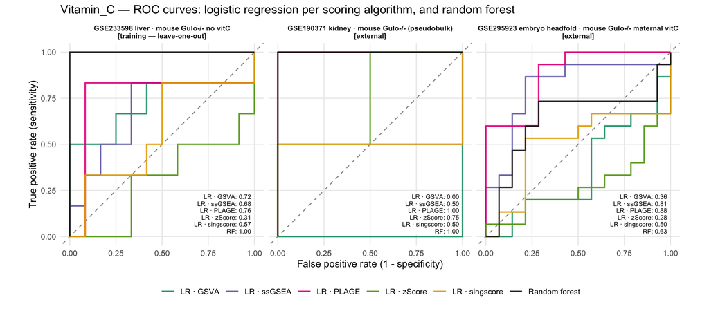

| Dataset | Validation | Model | AUC | 95% CI | Accuracy (p ≥ 0.5) | n case | n control |
| --- | --- | --- | --- | --- | --- | --- | --- |
| GSE233598 liver · mouse Gulo-/- no vitC | Internal (in-sample) | Score · GSVA | 0.72 | 0.40–1.00 | — | 6 | 12 |
|  |  | Score · ssGSEA | 0.76 | 0.53–1.00 | — | 6 | 12 |
|  |  | Score · PLAGE | 0.99 | 0.95–1.00 | — | 6 | 12 |
|  |  | Score · zScore | 0.58 | 0.25–0.91 | — | 6 | 12 |
|  |  | Score · singscore | 0.60 | 0.27–0.92 | — | 6 | 12 |
|  | Internal (LOOCV) | LR · GSVA | 0.72 | 0.40–1.00 | 0.72 | 6 | 12 |
|  |  | LR · ssGSEA | 0.68 | 0.36–1.00 | 0.67 | 6 | 12 |
|  |  | LR · PLAGE | 0.76 | 0.43–1.00 | 0.89 | 6 | 12 |
|  |  | LR · zScore | 0.31 | 0.02–0.60 | 0.44 | 6 | 12 |
|  |  | LR · singscore | 0.57 | 0.25–0.89 | 0.5 | 6 | 12 |
|  |  | Random forest | 1.00 | 1.00–1.00 | 0.94 | 6 | 12 |
|  | Internal (leave-pair-out) | LR · GSVA | 0.72 | — | — | 6 | 12 |
|  |  | LR · ssGSEA | 0.76 | — | — | 6 | 12 |
|  |  | LR · PLAGE | 0.95 | — | — | 6 | 12 |
|  |  | LR · zScore | 0.36 | — | — | 6 | 12 |
|  |  | LR · singscore | 0.60 | — | — | 6 | 12 |
|  |  | Random forest | 1.00 | — | — | 6 | 12 |
| GSE190371 kidney · mouse Gulo-/- (pseudobulk) | External | Score · GSVA | 0.00 | 0.00–0.00 | — | 2 | 2 |
|  |  | Score · ssGSEA | 0.50 | 0.00–1.00 | — | 2 | 2 |
|  |  | Score · PLAGE | 1.00 | 1.00–1.00 | — | 2 | 2 |
|  |  | Score · zScore | 0.75 | 0.06–1.00 | — | 2 | 2 |
|  |  | Score · singscore | 0.50 | 0.00–1.00 | — | 2 | 2 |
|  |  | LR · GSVA | 0.00 | 0.00–0.00 | 0.25 | 2 | 2 |
|  |  | LR · ssGSEA | 0.50 | 0.00–1.00 | 0.75 | 2 | 2 |
|  |  | LR · PLAGE | 1.00 | 1.00–1.00 | 1 | 2 | 2 |
|  |  | LR · zScore | 0.75 | 0.06–1.00 | 0.75 | 2 | 2 |
|  |  | LR · singscore | 0.50 | 0.00–1.00 | 0.5 | 2 | 2 |
|  |  | Random forest | 1.00 | 1.00–1.00 | 0.75 | 2 | 2 |
| GSE295923 embryo headfold · mouse Gulo-/- maternal vitC |  | Score · GSVA | 0.36 | 0.15–0.57 | — | 15 | 14 |
|  |  | Score · ssGSEA | 0.81 | 0.64–0.98 | — | 15 | 14 |
|  |  | Score · PLAGE | 0.88 | 0.75–1.00 | — | 15 | 14 |
|  |  | Score · zScore | 0.28 | 0.08–0.47 | — | 15 | 14 |
|  |  | Score · singscore | 0.50 | 0.27–0.73 | — | 15 | 14 |
|  |  | LR · GSVA | 0.36 | 0.15–0.57 | 0.41 | 15 | 14 |
|  |  | LR · ssGSEA | 0.81 | 0.64–0.98 | 0.76 | 15 | 14 |
|  |  | LR · PLAGE | 0.88 | 0.75–1.00 | 0.72 | 15 | 14 |
|  |  | LR · zScore | 0.28 | 0.08–0.47 | 0.34 | 15 | 14 |
|  |  | LR · singscore | 0.50 | 0.27–0.73 | 0.62 | 15 | 14 |
|  |  | Random forest | 0.63 | 0.41–0.86 | 0.66 | 15 | 14 |

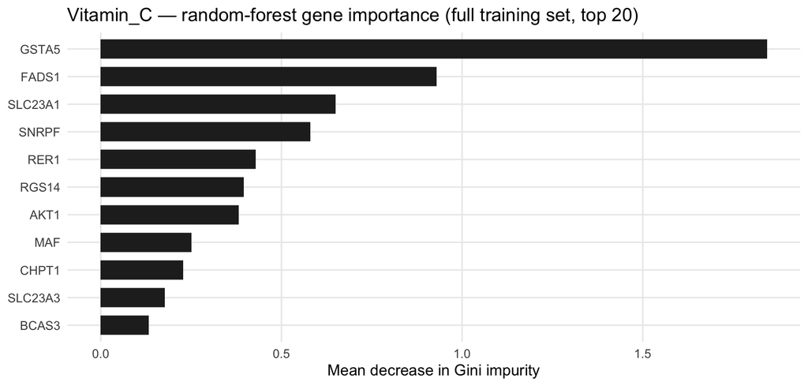

# Vitamin B12 / methyl donors

## B12_Cobalamin

*Source:* Curated (Signatures/NutSignaturesList.R)

*Panel:* Vitamin B12 / methyl donors · *Training set:* GSE161763 brain · mouse cblX (Ronin F80L) · *Signature size:* 10 genes · *Score direction learned in training:* GSVA lower in case; ssGSEA lower in case; PLAGE lower in case; zScore lower in case; singscore higher in case

| Dataset | Species | Signature genes | Found in data | Coverage |
| --- | --- | --- | --- | --- |
| GSE161763 brain · mouse cblX (Ronin F80L) | Mus musculus | 10 | 10 | 100% |
| GSE103417 N1E-115 · mouse B12 sequestration | Mus musculus | 10 | 10 | 100% |
| GSE104164 cerebellum · rat methyl-donor deficiency | Rattus norvegicus | 10 | 9 | 90% |
| GSE99113 astrocytes · mouse B12-free medium | Mus musculus | 10 | 10 | 100% |

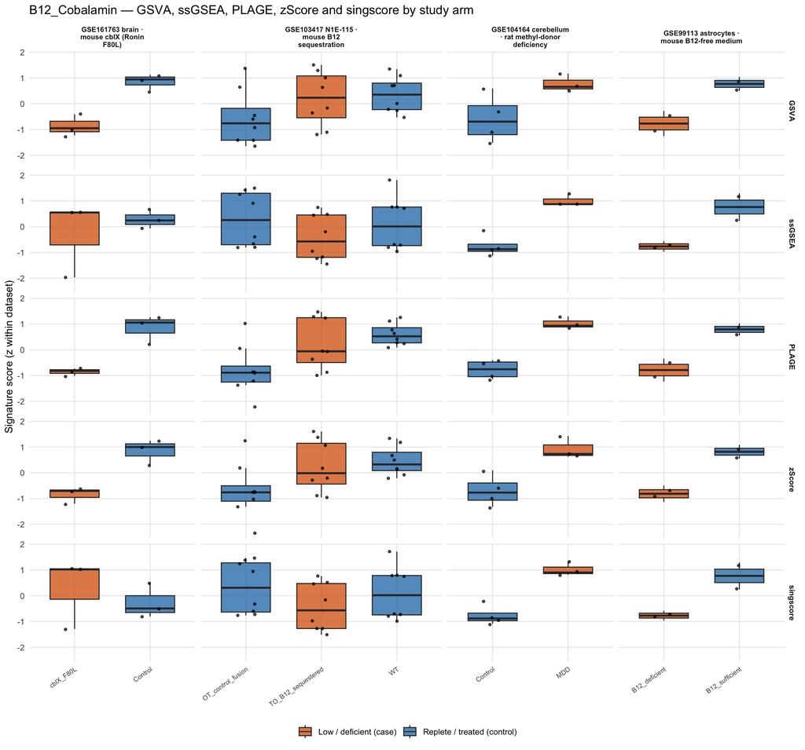

**ANOVA p-values.** *All arms* = one-way ANOVA across every study arm; *case vs control* = group effect after the listed covariates.

| Dataset | Role | Adjusted for | p (all arms) / p (case vs control) GSVA | p (all arms) / p (case vs control) ssGSEA | p (all arms) / p (case vs control) PLAGE | p (all arms) / p (case vs control) zScore | p (all arms) / p (case vs control) singscore |
| --- | --- | --- | --- | --- | --- | --- | --- |
| GSE161763 brain · mouse cblX (Ronin F80L) | Training | — | 0.005 / 0.005 | 0.548 / 0.548 | 0.006 / 0.006 | 0.007 / 0.007 | 0.575 / 0.575 |
| GSE103417 N1E-115 · mouse B12 sequestration | External | medium | 0.150 / 0.444 | 0.345 / 1.8e-04 | 0.009 / 0.445 | 0.043 / 0.375 | 0.310 / 5.3e-05 |
| GSE104164 cerebellum · rat methyl-donor deficiency | External | — | 0.066 / 0.066 | 0.001 / 0.001 | 8.0e-04 / 8.0e-04 | 0.012 / 0.012 | 0.001 / 0.001 |
| GSE99113 astrocytes · mouse B12-free medium | External | — | 0.112 / 0.112 | 0.117 / 0.117 | 0.088 / 0.088 | 0.058 / 0.058 | 0.109 / 0.109 |

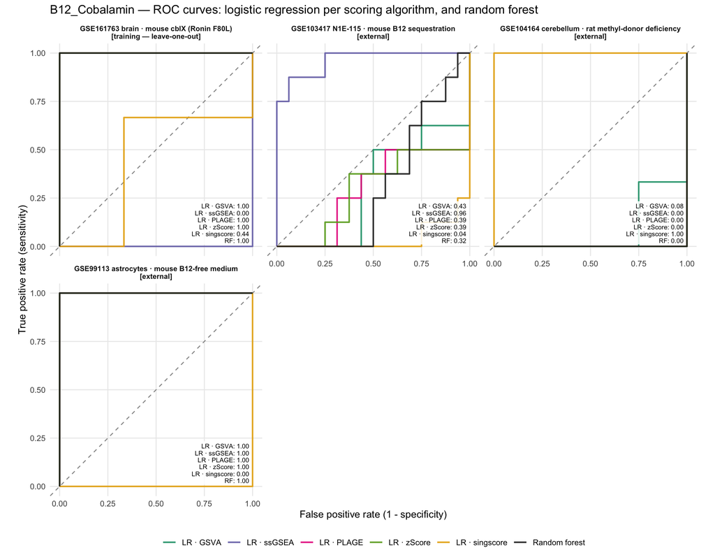

| Dataset | Validation | Model | AUC | 95% CI | Accuracy (p ≥ 0.5) | n case | n control |
| --- | --- | --- | --- | --- | --- | --- | --- |
| GSE161763 brain · mouse cblX (Ronin F80L) | Internal (in-sample) | Score · GSVA | 1.00 | 1.00–1.00 | — | 3 | 3 |
|  |  | Score · ssGSEA | 0.56 | 0.00–1.00 | — | 3 | 3 |
|  |  | Score · PLAGE | 1.00 | 1.00–1.00 | — | 3 | 3 |
|  |  | Score · zScore | 1.00 | 1.00–1.00 | — | 3 | 3 |
|  |  | Score · singscore | 0.67 | 0.01–1.00 | — | 3 | 3 |
|  | Internal (LOOCV) | LR · GSVA | 1.00 | 1.00–1.00 | 1 | 3 | 3 |
|  |  | LR · ssGSEA | 0.00 | 0.00–0.00 | 0.33 | 3 | 3 |
|  |  | LR · PLAGE | 1.00 | 1.00–1.00 | 1 | 3 | 3 |
|  |  | LR · zScore | 1.00 | 1.00–1.00 | 1 | 3 | 3 |
|  |  | LR · singscore | 0.44 | 0.00–1.00 | 0.67 | 3 | 3 |
|  |  | Random forest | 1.00 | 1.00–1.00 | 1 | 3 | 3 |
|  | Internal (leave-pair-out) | LR · GSVA | 1.00 | — | — | 3 | 3 |
|  |  | LR · ssGSEA | 0.22 | — | — | 3 | 3 |
|  |  | LR · PLAGE | 1.00 | — | — | 3 | 3 |
|  |  | LR · zScore | 1.00 | — | — | 3 | 3 |
|  |  | LR · singscore | 0.56 | — | — | 3 | 3 |
|  |  | Random forest | 1.00 | — | — | 3 | 3 |
| GSE103417 N1E-115 · mouse B12 sequestration | External | Score · GSVA | 0.37 | 0.14–0.60 | — | 8 | 16 |
|  |  | Score · ssGSEA | 0.96 | 0.89–1.00 | — | 8 | 16 |
|  |  | Score · PLAGE | 0.40 | 0.16–0.64 | — | 8 | 16 |
|  |  | Score · zScore | 0.39 | 0.15–0.63 | — | 8 | 16 |
|  |  | Score · singscore | 0.04 | 0.00–0.11 | — | 8 | 16 |
|  |  | LR · GSVA | 0.43 | 0.18–0.69 | 0.46 | 8 | 16 |
|  |  | LR · ssGSEA | 0.96 | 0.89–1.00 | 0.83 | 8 | 16 |
|  |  | LR · PLAGE | 0.39 | 0.16–0.62 | 0.46 | 8 | 16 |
|  |  | LR · zScore | 0.39 | 0.15–0.63 | 0.42 | 8 | 16 |
|  |  | LR · singscore | 0.04 | 0.00–0.11 | 0.17 | 8 | 16 |
|  |  | Random forest | 0.32 | 0.10–0.53 | 0.38 | 8 | 16 |
| GSE104164 cerebellum · rat methyl-donor deficiency |  | Score · GSVA | 0.08 | 0.00–0.31 | — | 3 | 4 |
|  |  | Score · ssGSEA | 0.00 | 0.00–0.00 | — | 3 | 4 |
|  |  | Score · PLAGE | 0.00 | 0.00–0.00 | — | 3 | 4 |
|  |  | Score · zScore | 0.00 | 0.00–0.00 | — | 3 | 4 |
|  |  | Score · singscore | 1.00 | 1.00–1.00 | — | 3 | 4 |
|  |  | LR · GSVA | 0.08 | 0.00–0.31 | 0.14 | 3 | 4 |
|  |  | LR · ssGSEA | 0.00 | 0.00–0.00 | 0 | 3 | 4 |
|  |  | LR · PLAGE | 0.00 | 0.00–0.00 | 0 | 3 | 4 |
|  |  | LR · zScore | 0.00 | 0.00–0.00 | 0.14 | 3 | 4 |
|  |  | LR · singscore | 1.00 | 1.00–1.00 | 1 | 3 | 4 |
|  |  | Random forest | 0.00 | 0.00–0.00 | 0.14 | 3 | 4 |
| GSE99113 astrocytes · mouse B12-free medium |  | Score · GSVA | 1.00 | 1.00–1.00 | — | 2 | 2 |
|  |  | Score · ssGSEA | 1.00 | 1.00–1.00 | — | 2 | 2 |
|  |  | Score · PLAGE | 1.00 | 1.00–1.00 | — | 2 | 2 |
|  |  | Score · zScore | 1.00 | 1.00–1.00 | — | 2 | 2 |
|  |  | Score · singscore | 0.00 | 0.00–0.00 | — | 2 | 2 |
|  |  | LR · GSVA | 1.00 | 1.00–1.00 | 1 | 2 | 2 |
|  |  | LR · ssGSEA | 1.00 | 1.00–1.00 | 1 | 2 | 2 |
|  |  | LR · PLAGE | 1.00 | 1.00–1.00 | 1 | 2 | 2 |
|  |  | LR · zScore | 1.00 | 1.00–1.00 | 1 | 2 | 2 |
|  |  | LR · singscore | 0.00 | 0.00–0.00 | 0 | 2 | 2 |
|  |  | Random forest | 1.00 | 1.00–1.00 | 1 | 2 | 2 |

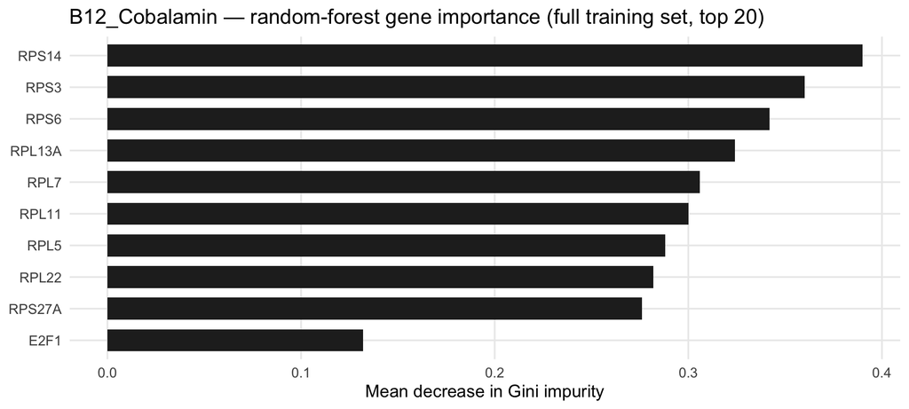

# Folate

## B9_Folate

*Source:* Curated (Signatures/NutSignaturesList.R)

*Panel:* Folate · *Training set:* GSE275393 E11.5 brain · mouse maternal FA 0.1 ppm · *Signature size:* 6 genes · *Score direction learned in training:* GSVA higher in case; ssGSEA higher in case; PLAGE higher in case; zScore higher in case; singscore higher in case

| Dataset | Species | Signature genes | Found in data | Coverage |
| --- | --- | --- | --- | --- |
| GSE275393 E11.5 brain · mouse maternal FA 0.1 ppm | Mus musculus | 6 | 6 | 100% |
| GSE324232 germ cells · mouse folate-deficient diet | Mus musculus | 6 | 6 | 100% |
| GSE104164 cerebellum · rat methyl-donor deficiency | Rattus norvegicus | 6 | 6 | 100% |
| GSE271941 MEF · mouse moderate vs fortified FA | Mus musculus | 6 | 6 | 100% |

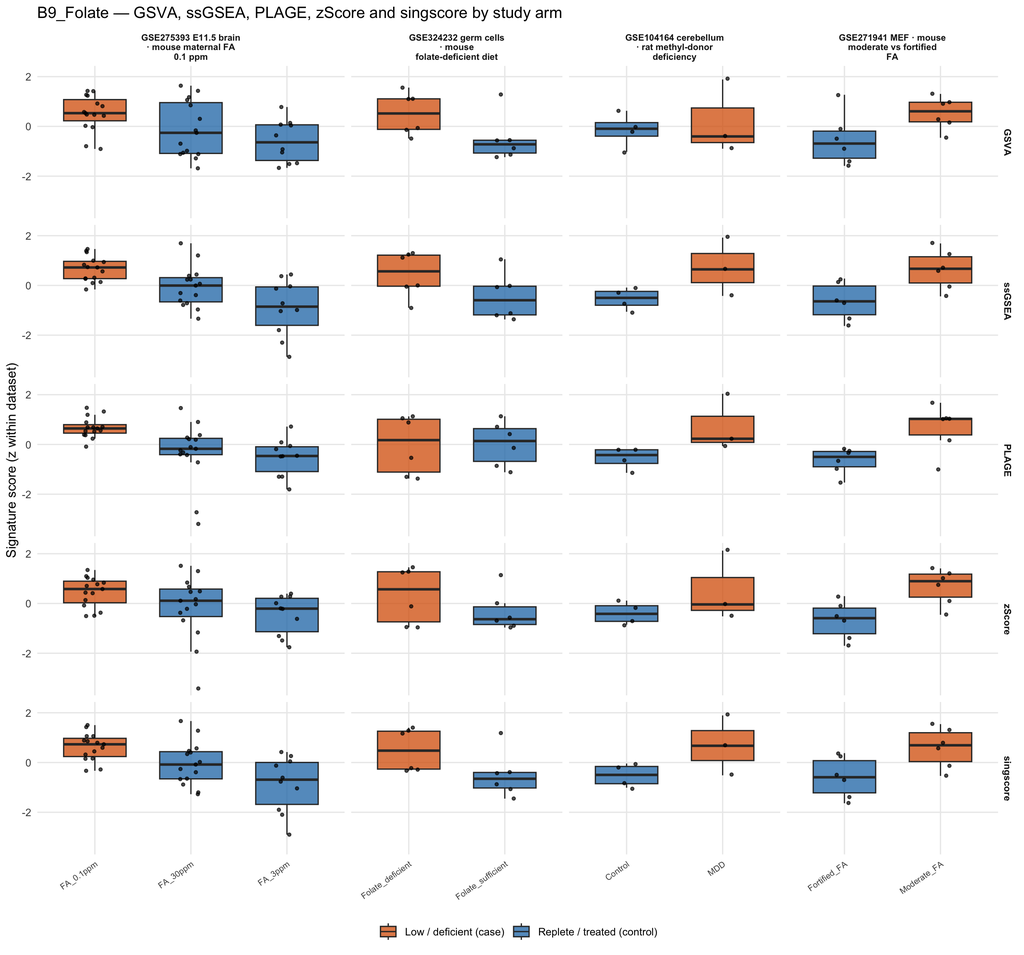

**ANOVA p-values.** *All arms* = one-way ANOVA across every study arm; *case vs control* = group effect after the listed covariates.

| Dataset | Role | Adjusted for | p (all arms) / p (case vs control) GSVA | p (all arms) / p (case vs control) ssGSEA | p (all arms) / p (case vs control) PLAGE | p (all arms) / p (case vs control) zScore | p (all arms) / p (case vs control) singscore |
| --- | --- | --- | --- | --- | --- | --- | --- |
| GSE275393 E11.5 brain · mouse maternal FA 0.1 ppm | Training | genotype, sex | 0.015 / 0.009 | 1.5e-04 / 8.4e-04 | 0.002 / 4.6e-04 | 0.056 / 0.025 | 3.9e-04 / 0.002 |
| GSE324232 germ cells · mouse folate-deficient diet | External | cell_type | 0.072 / 0.010 | 0.118 / 0.003 | 0.939 / 0.847 | 0.275 / 0.069 | 0.078 / 0.005 |
| GSE104164 cerebellum · rat methyl-donor deficiency | External | — | 0.695 / 0.695 | 0.100 / 0.100 | 0.088 / 0.088 | 0.265 / 0.265 | 0.122 / 0.122 |
| GSE271941 MEF · mouse moderate vs fortified FA | External | genotype | 0.060 / 0.070 | 0.019 / 0.025 | 0.014 / 0.017 | 0.010 / 0.013 | 0.031 / 0.039 |

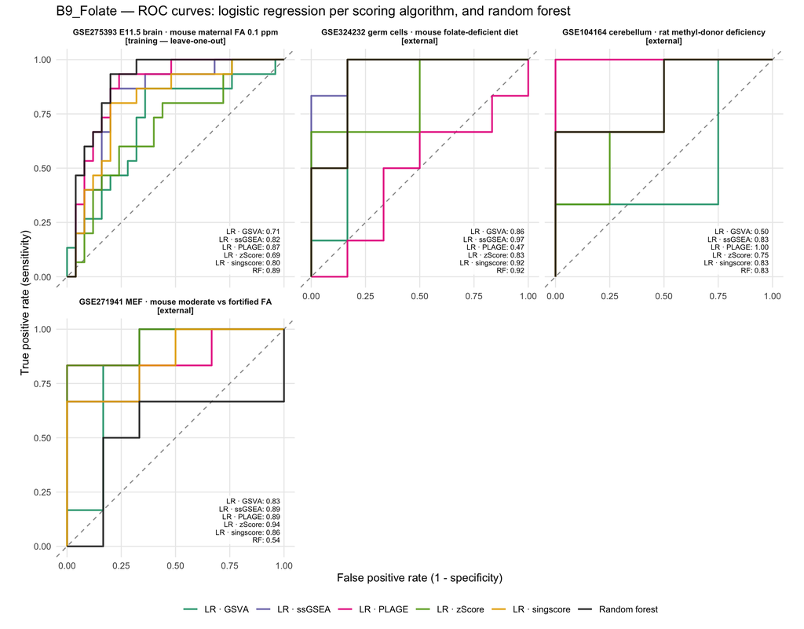

| Dataset | Validation | Model | AUC | 95% CI | Accuracy (p ≥ 0.5) | n case | n control |
| --- | --- | --- | --- | --- | --- | --- | --- |
| GSE275393 E11.5 brain · mouse maternal FA 0.1 ppm | Internal (in-sample) | Score · GSVA | 0.75 | 0.60–0.91 | — | 15 | 25 |
|  |  | Score · ssGSEA | 0.85 | 0.73–0.97 | — | 15 | 25 |
|  |  | Score · PLAGE | 0.89 | 0.79–0.99 | — | 15 | 25 |
|  |  | Score · zScore | 0.72 | 0.56–0.88 | — | 15 | 25 |
|  |  | Score · singscore | 0.82 | 0.69–0.96 | — | 15 | 25 |
|  | Internal (LOOCV) | LR · GSVA | 0.71 | 0.54–0.88 | 0.7 | 15 | 25 |
|  |  | LR · ssGSEA | 0.82 | 0.69–0.96 | 0.82 | 15 | 25 |
|  |  | LR · PLAGE | 0.87 | 0.76–0.98 | 0.8 | 15 | 25 |
|  |  | LR · zScore | 0.69 | 0.52–0.86 | 0.65 | 15 | 25 |
|  |  | LR · singscore | 0.80 | 0.66–0.94 | 0.78 | 15 | 25 |
|  |  | Random forest | 0.89 | 0.79–1.00 | 0.85 | 15 | 25 |
|  | Internal (leave-pair-out) | LR · GSVA | 0.75 | — | — | 15 | 25 |
|  |  | LR · ssGSEA | 0.85 | — | — | 15 | 25 |
|  |  | LR · PLAGE | 0.89 | — | — | 15 | 25 |
|  |  | LR · zScore | 0.72 | — | — | 15 | 25 |
|  |  | LR · singscore | 0.82 | — | — | 15 | 25 |
|  |  | Random forest | 0.91 | — | — | 15 | 25 |
| GSE324232 germ cells · mouse folate-deficient diet | External | Score · GSVA | 0.86 | 0.58–1.00 | — | 6 | 6 |
|  |  | Score · ssGSEA | 0.97 | 0.90–1.00 | — | 6 | 6 |
|  |  | Score · PLAGE | 0.47 | 0.11–0.84 | — | 6 | 6 |
|  |  | Score · zScore | 0.83 | 0.58–1.00 | — | 6 | 6 |
|  |  | Score · singscore | 0.92 | 0.74–1.00 | — | 6 | 6 |
|  |  | LR · GSVA | 0.86 | 0.58–1.00 | 0.92 | 6 | 6 |
|  |  | LR · ssGSEA | 0.97 | 0.90–1.00 | 0.83 | 6 | 6 |
|  |  | LR · PLAGE | 0.47 | 0.11–0.84 | 0.58 | 6 | 6 |
|  |  | LR · zScore | 0.83 | 0.58–1.00 | 0.75 | 6 | 6 |
|  |  | LR · singscore | 0.92 | 0.74–1.00 | 0.92 | 6 | 6 |
|  |  | Random forest | 0.92 | 0.74–1.00 | 0.75 | 6 | 6 |
| GSE104164 cerebellum · rat methyl-donor deficiency |  | Score · GSVA | 0.50 | 0.00–1.00 | — | 3 | 4 |
|  |  | Score · ssGSEA | 0.83 | 0.46–1.00 | — | 3 | 4 |
|  |  | Score · PLAGE | 1.00 | 1.00–1.00 | — | 3 | 4 |
|  |  | Score · zScore | 0.75 | 0.33–1.00 | — | 3 | 4 |
|  |  | Score · singscore | 0.83 | 0.46–1.00 | — | 3 | 4 |
|  |  | LR · GSVA | 0.50 | 0.00–1.00 | 0.57 | 3 | 4 |
|  |  | LR · ssGSEA | 0.83 | 0.46–1.00 | 0.86 | 3 | 4 |
|  |  | LR · PLAGE | 1.00 | 1.00–1.00 | 0.71 | 3 | 4 |
|  |  | LR · zScore | 0.75 | 0.33–1.00 | 0.71 | 3 | 4 |
|  |  | LR · singscore | 0.83 | 0.46–1.00 | 0.86 | 3 | 4 |
|  |  | Random forest | 0.83 | 0.46–1.00 | 0.71 | 3 | 4 |
| GSE271941 MEF · mouse moderate vs fortified FA |  | Score · GSVA | 0.83 | 0.55–1.00 | — | 6 | 6 |
|  |  | Score · ssGSEA | 0.89 | 0.69–1.00 | — | 6 | 6 |
|  |  | Score · PLAGE | 0.89 | 0.66–1.00 | — | 6 | 6 |
|  |  | Score · zScore | 0.94 | 0.82–1.00 | — | 6 | 6 |
|  |  | Score · singscore | 0.86 | 0.64–1.00 | — | 6 | 6 |
|  |  | LR · GSVA | 0.83 | 0.55–1.00 | 0.83 | 6 | 6 |
|  |  | LR · ssGSEA | 0.89 | 0.69–1.00 | 0.75 | 6 | 6 |
|  |  | LR · PLAGE | 0.89 | 0.66–1.00 | 0.92 | 6 | 6 |
|  |  | LR · zScore | 0.94 | 0.82–1.00 | 0.92 | 6 | 6 |
|  |  | LR · singscore | 0.86 | 0.64–1.00 | 0.67 | 6 | 6 |
|  |  | Random forest | 0.54 | 0.16–0.93 | 0.5 | 6 | 6 |

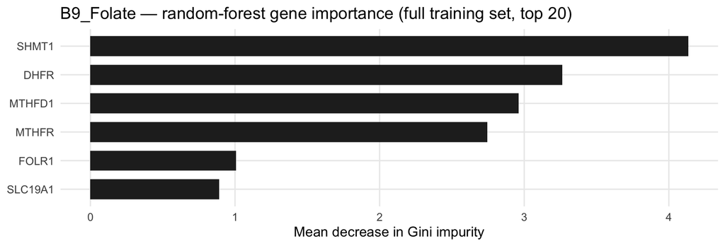

# Vitamin B6

## B6_Pyridoxine

*Source:* Curated (Signatures/NutSignaturesList.R)

*Panel:* Vitamin B6 · *Training set:* GSE345689 kidney · mouse low vs high B6 diet · *Signature size:* 9 genes · *Score direction learned in training:* GSVA higher in case; ssGSEA higher in case; PLAGE higher in case; zScore higher in case; singscore higher in case

| Dataset | Species | Signature genes | Found in data | Coverage |
| --- | --- | --- | --- | --- |
| GSE345689 kidney · mouse low vs high B6 diet | Mus musculus | 9 | 7 | 78% |
| GSE139892 leukemic cells · mouse B6 antagonist | Mus musculus | 9 | 4 | 44% |

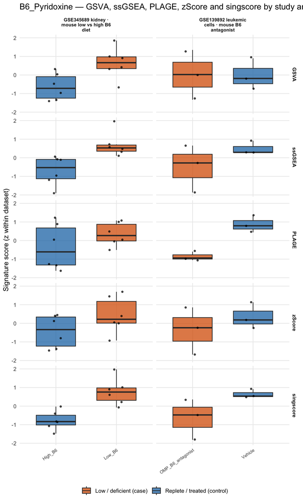

**ANOVA p-values.** *All arms* = one-way ANOVA across every study arm; *case vs control* = group effect after the listed covariates.

| Dataset | Role | Adjusted for | p (all arms) / p (case vs control) GSVA | p (all arms) / p (case vs control) ssGSEA | p (all arms) / p (case vs control) PLAGE | p (all arms) / p (case vs control) zScore | p (all arms) / p (case vs control) singscore |
| --- | --- | --- | --- | --- | --- | --- | --- |
| GSE345689 kidney · mouse low vs high B6 diet | Training | genotype | 0.018 / 0.010 | 0.008 / 8.5e-04 | 0.251 / 0.270 | 0.131 / 0.074 | 0.002 / 1.4e-04 |
| GSE139892 leukemic cells · mouse B6 antagonist | External | — | 0.976 / 0.976 | 0.264 / 0.264 | 0.004 / 0.004 | 0.447 / 0.447 | 0.117 / 0.117 |

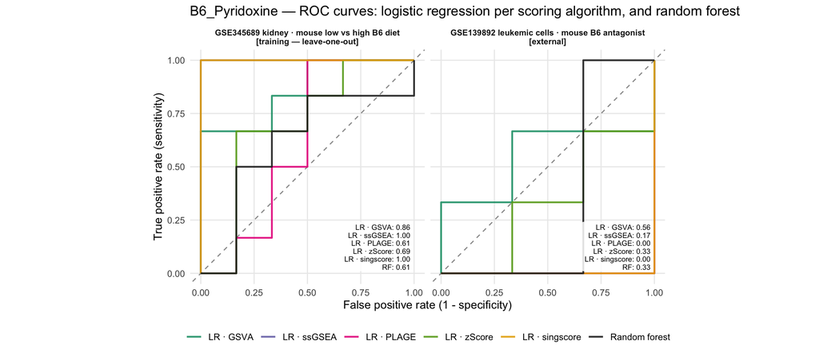

| Dataset | Validation | Model | AUC | 95% CI | Accuracy (p ≥ 0.5) | n case | n control |
| --- | --- | --- | --- | --- | --- | --- | --- |
| GSE345689 kidney · mouse low vs high B6 diet | Internal (in-sample) | Score · GSVA | 0.92 | 0.76–1.00 | — | 6 | 6 |
|  |  | Score · ssGSEA | 1.00 | 1.00–1.00 | — | 6 | 6 |
|  |  | Score · PLAGE | 0.69 | 0.36–1.00 | — | 6 | 6 |
|  |  | Score · zScore | 0.81 | 0.54–1.00 | — | 6 | 6 |
|  |  | Score · singscore | 1.00 | 1.00–1.00 | — | 6 | 6 |
|  | Internal (LOOCV) | LR · GSVA | 0.86 | 0.64–1.00 | 0.67 | 6 | 6 |
|  |  | LR · ssGSEA | 1.00 | 1.00–1.00 | 1 | 6 | 6 |
|  |  | LR · PLAGE | 0.61 | 0.23–0.99 | 0.5 | 6 | 6 |
|  |  | LR · zScore | 0.69 | 0.35–1.00 | 0.75 | 6 | 6 |
|  |  | LR · singscore | 1.00 | 1.00–1.00 | 1 | 6 | 6 |
|  |  | Random forest | 0.61 | 0.24–0.98 | 0.67 | 6 | 6 |
|  | Internal (leave-pair-out) | LR · GSVA | 0.92 | — | — | 6 | 6 |
|  |  | LR · ssGSEA | 1.00 | — | — | 6 | 6 |
|  |  | LR · PLAGE | 0.69 | — | — | 6 | 6 |
|  |  | LR · zScore | 0.81 | — | — | 6 | 6 |
|  |  | LR · singscore | 1.00 | — | — | 6 | 6 |
|  |  | Random forest | 0.68 | — | — | 6 | 6 |
| GSE139892 leukemic cells · mouse B6 antagonist | External | Score · GSVA | 0.56 | 0.00–1.00 | — | 3 | 3 |
|  |  | Score · ssGSEA | 0.22 | 0.00–0.71 | — | 3 | 3 |
|  |  | Score · PLAGE | 0.00 | 0.00–0.00 | — | 3 | 3 |
|  |  | Score · zScore | 0.33 | 0.00–0.87 | — | 3 | 3 |
|  |  | Score · singscore | 0.00 | 0.00–0.00 | — | 3 | 3 |
|  |  | LR · GSVA | 0.56 | 0.00–1.00 | 0.67 | 3 | 3 |
|  |  | LR · ssGSEA | 0.17 | 0.00–0.49 | 0.17 | 3 | 3 |
|  |  | LR · PLAGE | 0.00 | 0.00–0.00 | 0 | 3 | 3 |
|  |  | LR · zScore | 0.33 | 0.00–0.87 | 0.33 | 3 | 3 |
|  |  | LR · singscore | 0.00 | 0.00–0.00 | 0.17 | 3 | 3 |
|  |  | Random forest | 0.33 | 0.00–0.99 | 0.33 | 3 | 3 |

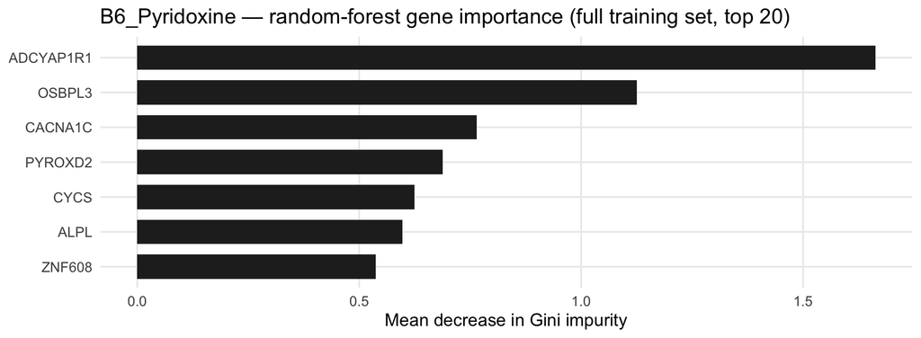

# Vitamin E

## Vitamin_E

*Source:* Curated (Signatures/NutSignaturesList.R)

*Panel:* Vitamin E · *Training set:* GSE110747 liver · mouse vitamin E diet · *Signature size:* 11 genes · *Score direction learned in training:* GSVA lower in case; ssGSEA higher in case; PLAGE lower in case; zScore lower in case; singscore lower in case

| Dataset | Species | Signature genes | Found in data | Coverage |
| --- | --- | --- | --- | --- |
| GSE110747 liver · mouse vitamin E diet | Mus musculus | 11 | 7 | 64% |
| GSE1063 · rat vitamin E-deficient diet | Rattus norvegicus | 11 | 0 | 0% |
| GSE8150 brain · aged mouse tocopherol | Mus musculus | 11 | 7 | 64% |
| GSE8146 heart · aged mouse tocopherol | Mus musculus | 11 | 5 | 45% |
| GSE195619 HepaRG · human oleic acid ± vitamin E | Homo sapiens | 11 | 7 | 64% |

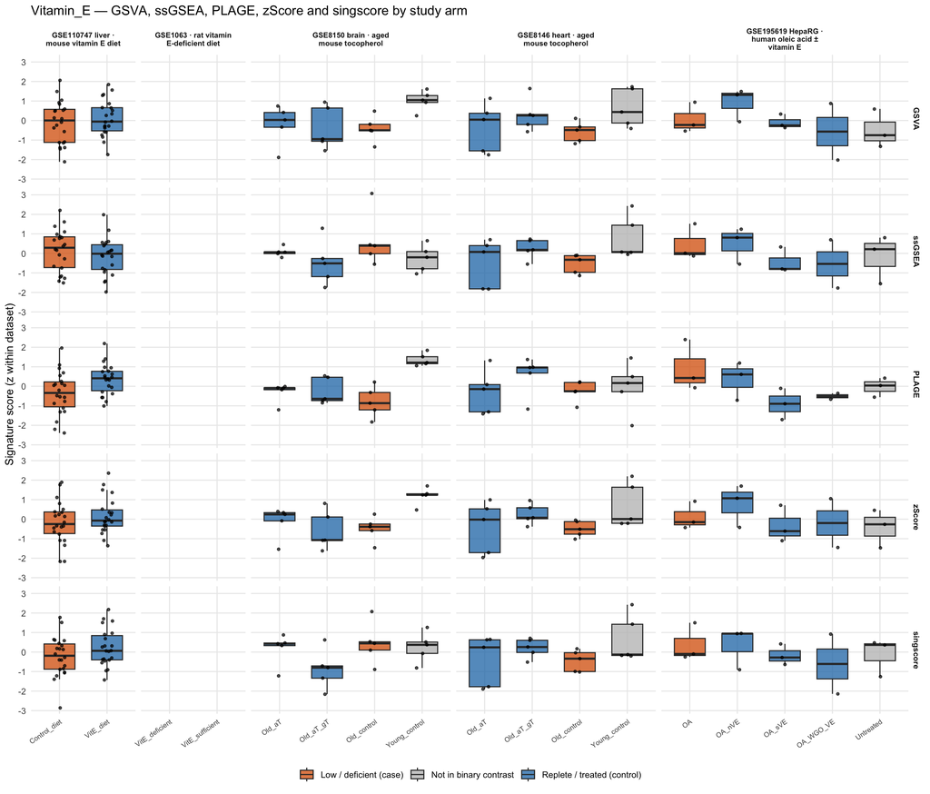

**ANOVA p-values.** *All arms* = one-way ANOVA across every study arm; *case vs control* = group effect after the listed covariates.

| Dataset | Role | Adjusted for | p (all arms) / p (case vs control) GSVA | p (all arms) / p (case vs control) ssGSEA | p (all arms) / p (case vs control) PLAGE | p (all arms) / p (case vs control) zScore | p (all arms) / p (case vs control) singscore |
| --- | --- | --- | --- | --- | --- | --- | --- |
| GSE110747 liver · mouse vitamin E diet | Training | exercise | 0.490 / 0.491 | 0.327 / 0.331 | 0.017 / 0.019 | 0.278 / 0.284 | 0.147 / 0.151 |
| GSE1063 · rat vitamin E-deficient diet | External | — | — / — | — / — | — / — | — / — | — / — |
| GSE8150 brain · aged mouse tocopherol | External | — | 0.053 / 0.822 | 0.304 / 0.151 | 2.1e-04 / 0.163 | 0.006 / 0.769 | 0.144 / 0.183 |
| GSE8146 heart · aged mouse tocopherol | External | — | 0.183 / 0.300 | 0.100 / 0.407 | 0.546 / 0.490 | 0.185 / 0.419 | 0.231 / 0.498 |
| GSE195619 HepaRG · human oleic acid ± vitamin E | External | — | 0.474 / 0.889 | 0.690 / 0.421 | 0.203 / 0.101 | 0.657 / 0.995 | 0.852 / 0.532 |

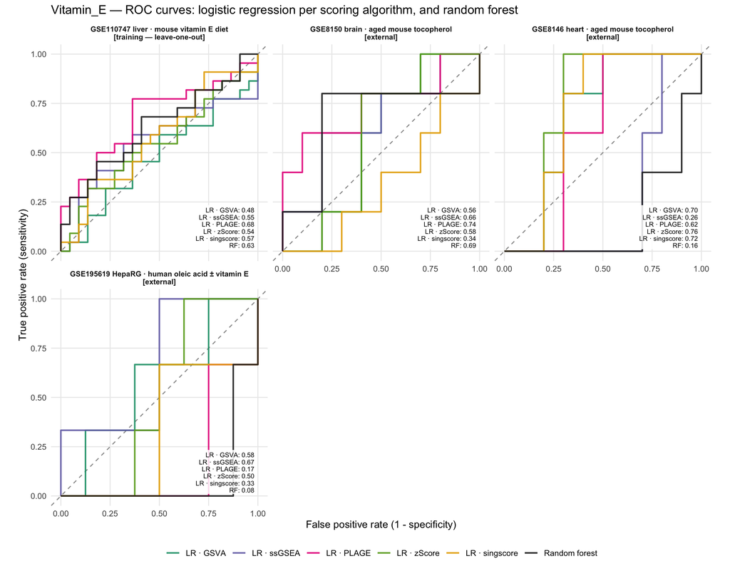

| Dataset | Validation | Model | AUC | 95% CI | Accuracy (p ≥ 0.5) | n case | n control |
| --- | --- | --- | --- | --- | --- | --- | --- |
| GSE110747 liver · mouse vitamin E diet | Internal (in-sample) | Score · GSVA | 0.56 | 0.39–0.74 | — | 22 | 22 |
|  |  | Score · ssGSEA | 0.60 | 0.42–0.77 | — | 22 | 22 |
|  |  | Score · PLAGE | 0.70 | 0.54–0.85 | — | 22 | 22 |
|  |  | Score · zScore | 0.58 | 0.41–0.76 | — | 22 | 22 |
|  |  | Score · singscore | 0.60 | 0.43–0.77 | — | 22 | 22 |
|  | Internal (LOOCV) | LR · GSVA | 0.48 | 0.30–0.65 | 0.55 | 22 | 22 |
|  |  | LR · ssGSEA | 0.55 | 0.37–0.73 | 0.55 | 22 | 22 |
|  |  | LR · PLAGE | 0.68 | 0.52–0.84 | 0.59 | 22 | 22 |
|  |  | LR · zScore | 0.54 | 0.37–0.72 | 0.5 | 22 | 22 |
|  |  | LR · singscore | 0.57 | 0.40–0.74 | 0.57 | 22 | 22 |
|  |  | Random forest | 0.63 | 0.46–0.80 | 0.64 | 22 | 22 |
|  | Internal (leave-pair-out) | LR · GSVA | 0.56 | — | — | 22 | 22 |
|  |  | LR · ssGSEA | 0.60 | — | — | 22 | 22 |
|  |  | LR · PLAGE | 0.70 | — | — | 22 | 22 |
|  |  | LR · zScore | 0.58 | — | — | 22 | 22 |
|  |  | LR · singscore | 0.60 | — | — | 22 | 22 |
|  |  | Random forest | 0.66 | — | — | 22 | 22 |
| GSE8150 brain · aged mouse tocopherol | External | Score · GSVA | 0.56 | 0.26–0.86 | — | 5 | 10 |
|  |  | Score · ssGSEA | 0.66 | 0.33–0.99 | — | 5 | 10 |
|  |  | Score · PLAGE | 0.74 | 0.42–1.00 | — | 5 | 10 |
|  |  | Score · zScore | 0.58 | 0.27–0.89 | — | 5 | 10 |
|  |  | Score · singscore | 0.34 | 0.03–0.65 | — | 5 | 10 |
|  |  | LR · GSVA | 0.56 | 0.26–0.86 | 0.53 | 5 | 10 |
|  |  | LR · ssGSEA | 0.66 | 0.33–0.99 | 0.73 | 5 | 10 |
|  |  | LR · PLAGE | 0.74 | 0.42–1.00 | 0.6 | 5 | 10 |
|  |  | LR · zScore | 0.58 | 0.27–0.89 | 0.53 | 5 | 10 |
|  |  | LR · singscore | 0.34 | 0.03–0.65 | 0.4 | 5 | 10 |
|  |  | Random forest | 0.69 | 0.33–1.00 | 0.73 | 5 | 10 |
| GSE8146 heart · aged mouse tocopherol |  | Score · GSVA | 0.70 | 0.42–0.98 | — | 5 | 10 |
|  |  | Score · ssGSEA | 0.26 | 0.00–0.53 | — | 5 | 10 |
|  |  | Score · PLAGE | 0.62 | 0.32–0.92 | — | 5 | 10 |
|  |  | Score · zScore | 0.76 | 0.50–1.00 | — | 5 | 10 |
|  |  | Score · singscore | 0.72 | 0.45–0.99 | — | 5 | 10 |
|  |  | LR · GSVA | 0.70 | 0.42–0.98 | 0.73 | 5 | 10 |
|  |  | LR · ssGSEA | 0.26 | 0.00–0.53 | 0.33 | 5 | 10 |
|  |  | LR · PLAGE | 0.62 | 0.32–0.92 | 0.6 | 5 | 10 |
|  |  | LR · zScore | 0.76 | 0.50–1.00 | 0.67 | 5 | 10 |
|  |  | LR · singscore | 0.72 | 0.45–0.99 | 0.67 | 5 | 10 |
|  |  | Random forest | 0.16 | 0.00–0.37 | 0.27 | 5 | 10 |
| GSE195619 HepaRG · human oleic acid ± vitamin E |  | Score · GSVA | 0.58 | 0.15–1.00 | — | 3 | 8 |
|  |  | Score · ssGSEA | 0.67 | 0.26–1.00 | — | 3 | 8 |
|  |  | Score · PLAGE | 0.17 | 0.00–0.44 | — | 3 | 8 |
|  |  | Score · zScore | 0.50 | 0.14–0.86 | — | 3 | 8 |
|  |  | Score · singscore | 0.33 | 0.00–0.74 | — | 3 | 8 |
|  |  | LR · GSVA | 0.58 | 0.15–1.00 | 0.55 | 3 | 8 |
|  |  | LR · ssGSEA | 0.67 | 0.26–1.00 | 0.45 | 3 | 8 |
|  |  | LR · PLAGE | 0.17 | 0.00–0.44 | 0.27 | 3 | 8 |
|  |  | LR · zScore | 0.50 | 0.14–0.86 | 0.55 | 3 | 8 |
|  |  | LR · singscore | 0.33 | 0.00–0.74 | 0.55 | 3 | 8 |
|  |  | Random forest | 0.08 | 0.00–0.27 | 0.18 | 3 | 8 |

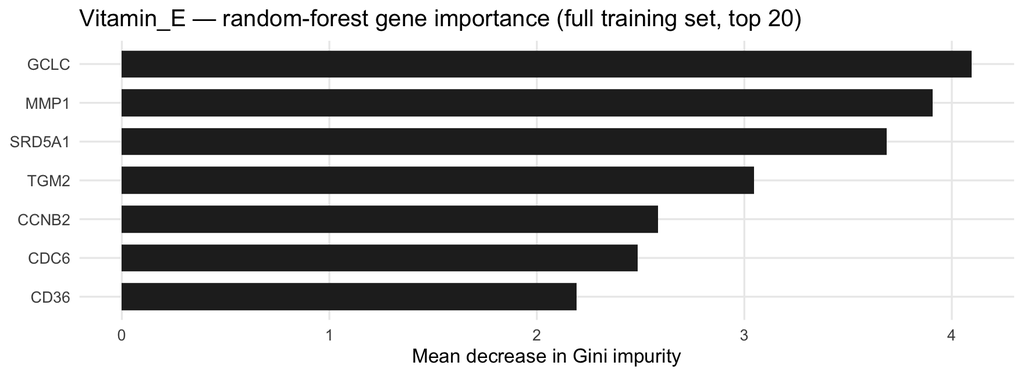

## Vitamin_E_Curated_Fixed

*Source:* Candidate — NutSignatures$Vitamin_E (curated); CDC2 -> CDK1, PKC -> PRKCA; MIR122/MIR125B kept (not on mRNA platforms)